# Wrangle and Analyze WeRateDogs Twitter data

## 1. Gathering Data

### 1.1 Load `twitter_archive_enhanced.csv`

```python
import pandas as pd
```

```python
# load csv file into datafram 'twitter_enhanced'
twitter_enhanced = pd.read_csv('twitter-archive-enhanced.csv')
```

### 1.2 Download `image_predictions.tsv` from [URL](https://d17h27t6h515a5.cloudfront.net/topher/2017/August/599fd2ad_image-predictions/image-predictions.tsv)

```python
import requests
```

```python
# use requests module to download image-predictions.tsv, load the tsv file into datafram
url = 'https://d17h27t6h515a5.cloudfront.net/topher/2017/August/599fd2ad_image-predictions/image-predictions.tsv'
response = requests.get(url)

with open ('image-predictions.tsv',mode = 'wb') as file:
    file.write(response.content)
```

```python
# load tsv file into datafram 'image_predictions'
image_predictions = pd.read_csv('image-predictions.tsv', sep = '\t')
```

### 1.3 Download tweet data from API, save to `tweet_json.txt`, set a Datafram

```python
import tweepy
import json
```

```python
# Followed the request, I delete all true information.
consumer_key = 'my consumer key'
consumer_secret = 'my consumer secret'
access_token = 'my access token'
access_secret = 'my access secret'
```

```python
# scrap all tweet with the same tweet_id in `twitter_enhanced`
auth = tweepy.OAuthHandler(consumer_key, consumer_secret)
auth.set_access_token(access_token, access_secret)
api = tweepy.API(auth, wait_on_rate_limit = True, wait_on_rate_limit_notify = True)
```

```python
n = 1
for tweid in twitter_enhanced.tweet_id:
    with open('tweet_json.txt','a' ) as file:
        try:
            tweet = api.get_status(tweid, tweet_mode='extended')
            json_tweet = json.dumps(tweet._json)
            file.write(json_tweet + '\n')
        except:
            file.write( 'Date has been deleted. \n')
    print('No.' , '{:>5}'.format(n) , tweid ,' finished')
    n += 1
```

[output not shown]

[output cut: 824 more lines]

[output not shown]

```
Rate limit reached. Sleeping for: 404
```

[output not shown]

[output cut: 846 more lines]

[output not shown]

```
Rate limit reached. Sleeping for: 615
```

[output not shown]

[output cut: 521 more lines]

[output not shown]

I have saved all the possible files from API. Then, I open this txt file with jupyter notebook, and use 'control+F' to look for columns I need.

I find if this tweet is a retweet, it will have a 'retweeted_status' sub_dict. I found the tweet with index 68 is a retweet, so I use json format to print a tweet and a retweet to find some details.

```python
#print a tweet and a retweet with json format
with open('tweet_json.txt','r') as jsfile:
    lines = jsfile.readlines()
    js_line1 = json.loads(lines[0])
    js_line2 = json.loads(lines[68])

print(json.dumps(js_line1,indent=4))
print('-----------------------------')
print(json.dumps(js_line2,indent=4))
```

```
{
    "created_at": "Tue Aug 01 16:23:56 +0000 2017",
    "id": 892420643555336193,
    "id_str": "892420643555336193",
    "full_text": "This is Phineas. He's a mystical boy. Only ever appears in the hole of a donut. 13/10 https://t.co/MgUWQ76dJU",
    "truncated": false,
    "display_text_range": [
        0,
        85
    ],
    "entities": {
        "hashtags": [],
        "symbols": [],
        "user_mentions": [],
        "urls": [],
        "media": [
            {
                "id": 892420639486877696,
                "id_str": "892420639486877696",
                "indices": [
                    86,
                    109
                ],
                "media_url": "http://pbs.twimg.com/media/DGKD1-bXoAAIAUK.jpg",
                "media_url_https": "https://pbs.twimg.com/media/DGKD1-bXoAAIAUK.jpg",
                "url": "https://t.co/MgUWQ76dJU",
                "display_url": "pic.twitter.com/MgUWQ76dJU",
                "expanded_url": "https://twitter.com/dog_rates/status/892420643555336193/photo/1",
                "type": "photo",
                "sizes": {
                    "thumb": {
                        "w": 150,
                        "h": 150,
                        "resize": "crop"
                    },
                    "medium": {
                        "w": 540,
                        "h": 528,
                        "resize": "fit"
                    },
```

[output cut: 567 more lines]

```
        "retweet_count": 6321,
        "favorite_count": 40074,
        "favorited": false,
        "retweeted": false,
        "possibly_sensitive": false,
        "possibly_sensitive_appealable": false,
        "lang": "en"
    },
    "is_quote_status": false,
    "retweet_count": 6321,
    "favorite_count": 0,
    "favorited": false,
    "retweeted": false,
    "lang": "en"
}
```

I copy the json formate text into Atom。

I find for tweet, all necessary contents are in the first level of the nested dicitonary. But if the tweet is a retweet, the 'favorite_count' and original ID is in the sub_dicitonary with keyname 'retweeted_status'

```python
# Load 'full_text', 'tweet_id', 'retweet_count', 'favorite_count',
#'in_reply_to_status_id', 'retweeted_status_id' from 'tweet_json.txt',
# and save them as a dicitonary in a list

df_list = [] #set a empty list

with open('tweet_json.txt','r') as jsfile:
    for line in jsfile:
        try:
            jline = json.loads(line)  #load every row of the txt file in json mode
            full_text = jline["full_text"]
            tweet_id = jline["id_str"]
            in_reply_to_status_id = jline["in_reply_to_status_id_str"]

            if jline.get('retweeted_status') is None:  # if this tweet is not a retweet
                retweet_count = jline["retweet_count"]
                favorite_count = jline["favorite_count"]
                retweeted_status_id = None

            else:   # if this tweet is a retweet
                retweet_count = jline['retweeted_status']["retweet_count"]
                favorite_count = jline['retweeted_status']['favorite_count']
                retweeted_status_id = jline['retweeted_status']["id_str"]

            df_list.append({'tweet_id':tweet_id,
                            'full_text': full_text,
                            'retweet_count':retweet_count,
                            'favorite_count':favorite_count,
                            'in_reply_to_status_id':in_reply_to_status_id,
                            'retweeted_status_id' : retweeted_status_id})
        except:
            continue

#change df_list into a datafram called 'supplement'
supplement = pd.DataFrame(df_list)
```

## 2. Assessing Data

```python
#let jupyter notebook show whole text and enough rows
pd.set_option('display.max_colwidth', -1)
pd.set_option('display.max_rows', 500)
```

### 2.1 visually assess for quality

This we rate dog dataset comes in three tables: `twitter_enhanced`,`image_predictions`and `supplement`.

```python
# took some sample from twitter_enhanced
twitter_enhanced.sample(10)
```

|  | tweet_id | in_reply_to_status_id | in_reply_to_user_id | timestamp | source | text | retweeted_status_id | retweeted_status_user_id | retweeted_status_timestamp | expanded_urls | rating_numerator | rating_denominator | name | doggo | floofer | pupper | puppo |
| --- | --- | --- | --- | --- | --- | --- | --- | --- | --- | --- | --- | --- | --- | --- | --- | --- | --- |
| 1558 | 688789766343622656 | NaN | NaN | 2016-01-17 18:27:32 +0000 | <a href="http://twitter.com/download/iphone" rel="nofollow">Twitter for iPhone</a> | Meet Pubert. He's a Kerplunk Rumplestilt. Cannot comprehend flower. Flawless tongue. 8/10 would pat head approvingly https://t.co/2TWxg0rgyG | NaN | NaN | NaN | https://twitter.com/dog_rates/status/688789766343622656/photo/1 | 8 | 10 | Pubert | None | None | None | None |
| 390 | 826240494070030336 | NaN | NaN | 2017-01-31 01:27:39 +0000 | <a href="http://twitter.com/download/iphone" rel="nofollow">Twitter for iPhone</a> | We only rate dogs. Please don't send in any more non-dogs like this Wild Albanian Street Moose. Thank you... 11/10 https://t.co/srXL2s868C | NaN | NaN | NaN | https://twitter.com/dog_rates/status/826240494070030336/photo/1 | 11 | 10 | None | None | None | None | None |
| 772 | 776477788987613185 | NaN | NaN | 2016-09-15 17:48:25 +0000 | <a href="http://twitter.com/download/iphone" rel="nofollow">Twitter for iPhone</a> | This is Huck. He's addicted to caffeine. Hope it's not too latte to seek help. 11/10 stay strong pupper https://t.co/iJE3F0VozW | NaN | NaN | NaN | https://twitter.com/dog_rates/status/776477788987613185/photo/1,https://twitter.com/dog_rates/status/776477788987613185/photo/1 | 11 | 10 | Huck | None | None | pupper | None |
| 327 | 833732339549220864 | NaN | NaN | 2017-02-20 17:37:34 +0000 | <a href="http://twitter.com/download/iphone" rel="nofollow">Twitter for iPhone</a> | RT @rolltidered: This is Gabby. Now requests to be referred to as a guide dog, thanks to @dog_rates and @ShopWeRateDogs. 12/10 in my book.… | 8.324344e+17 | 44667502.0 | 2017-02-17 03:39:51 +0000 | https://twitter.com/rolltidered/status/832434358292209665/photo/1 | 12 | 10 | Gabby | None | None | None | None |
| 1302 | 707610948723478529 | NaN | NaN | 2016-03-09 16:56:11 +0000 | <a href="http://twitter.com/download/iphone" rel="nofollow">Twitter for iPhone</a> | This is Harper. She scraped her elbow attempting a backflip off a tree. Valiant effort tho. 12/10 https://t.co/oHKJHghrp5 | NaN | NaN | NaN | https://twitter.com/dog_rates/status/707610948723478529/photo/1 | 12 | 10 | Harper | None | None | None | None |
| 1353 | 703769065844768768 | NaN | NaN | 2016-02-28 02:29:55 +0000 | <a href="http://twitter.com/download/iphone" rel="nofollow">Twitter for iPhone</a> | When you're trying to watch your favorite tv show but your friends keep interrupting. 10/10 relatable af https://t.co/QQZDCYl6zT | NaN | NaN | NaN | https://twitter.com/dog_rates/status/703769065844768768/photo/1,https://twitter.com/dog_rates/status/703769065844768768/photo/1 | 10 | 10 | None | None | None | None | None |
| 393 | 825876512159186944 | NaN | NaN | 2017-01-30 01:21:19 +0000 | <a href="http://twitter.com/download/iphone" rel="nofollow">Twitter for iPhone</a> | This is Mo. No one will push him around in the grocery cart. He's quite pupset about it. 11/10 I volunteer https://t.co/feNwTq12S5 | NaN | NaN | NaN | https://twitter.com/dog_rates/status/825876512159186944/photo/1 | 11 | 10 | Mo | None | None | None | None |
| 848 | 766069199026450432 | NaN | NaN | 2016-08-18 00:28:24 +0000 | <a href="http://twitter.com/download/iphone" rel="nofollow">Twitter for iPhone</a> | This is Juno. She can see your future. 12/10 h*ckin mesmerizing af https://t.co/Z69mShifuk | NaN | NaN | NaN | https://twitter.com/dog_rates/status/766069199026450432/photo/1 | 12 | 10 | Juno | None | None | None | None |
| 1996 | 672591762242805761 | NaN | NaN | 2015-12-04 01:42:26 +0000 | <a href="http://twitter.com/download/iphone" rel="nofollow">Twitter for iPhone</a> | This is Taz. He boxes leaves. 10/10 https://t.co/bWQ0iIcP0w | NaN | NaN | NaN | https://twitter.com/dog_rates/status/672591762242805761/photo/1 | 10 | 10 | Taz | None | None | None | None |
| 1438 | 696900204696625153 | NaN | NaN | 2016-02-09 03:35:31 +0000 | <a href="http://twitter.com/download/iphone" rel="nofollow">Twitter for iPhone</a> | This is Rosie. She's a Benebark Cumberpatch. Sleepy af. 12/10 would snug for days https://t.co/NKuON5Al8i | NaN | NaN | NaN | https://twitter.com/dog_rates/status/696900204696625153/photo/1 | 12 | 10 | Rosie | None | None | None | None |

`twitter_enhanced` have the following columns

- **tweet_id** The integer representation of the unique identifier for this Tweet
- **in_reply_to_status_id** If the represented Tweet is a reply, this is the original Tweet’s ID
- **in_reply_to_user_id** If the represented Tweet is a reply, this is the original Tweet’s author ID
- **timestamp** the timestamp when this Tweet was posted
- **source** Utility used to post the Tweet
- **text** The actual UTF-8 text of the status update.
- **retweeted_status_id** If the represented Tweet is a reteweet,this is the original Tweet’s ID
- **retweeted_status_user_id** If the represented Tweet is a reteweet, this is the original Tweet’s author ID
- **retweeted_status_timestamp** the original Tweet’s timestamp
- **expanded_urls** the expanded_urls of this tweet_id
- **rating_numerator** and **rating_denominator** are the two parts of rating score form the text
- **name** the dog's name
- **doggo**,**floofer**,**pupper** and **puppo** are the stages of the dog

### Quality issues

- For **retweeted_status_id** and **in_reply_to_status_id** columns, non-null value means this tweet is a retweet or reply. I am not sure wether their original tweet is already in the dataset, I need to do programmatic research to decide if I should delete these rows. Before I can compair these columns with 'tweet_id' column, I should deal with some 'digits missing' problem of the two columns(the value are in '*.**E+17' form, and missing most of its digits)
- **source** column has several html tag characters, and is not good for further analysis
- **name，doggo，floofer，pupper，puppo** column have many 'None' value

```python
# took some sample from image_predictions
image_predictions.sample(10)
```

|  | tweet_id | jpg_url | img_num | p1 | p1_conf | p1_dog | p2 | p2_conf | p2_dog | p3 | p3_conf | p3_dog |
| --- | --- | --- | --- | --- | --- | --- | --- | --- | --- | --- | --- | --- |
| 1029 | 711008018775851008 | https://pbs.twimg.com/media/Cd4CBQFW8AAY3ND.jpg | 1 | French_bulldog | 0.731405 | True | Boston_bull | 0.150672 | True | pug | 0.021811 | True |
| 730 | 686618349602762752 | https://pbs.twimg.com/media/CYdbvwjWcAEtjYu.jpg | 1 | Rottweiler | 0.441331 | True | miniature_pinscher | 0.233180 | True | Gordon_setter | 0.093582 | True |
| 402 | 673697980713705472 | https://pbs.twimg.com/media/CVl0vFeWoAAMTfg.jpg | 1 | porcupine | 0.151876 | False | hen | 0.111380 | False | doormat | 0.058934 | False |
| 621 | 680494726643068929 | https://pbs.twimg.com/media/CXGaVxOWAAADjhF.jpg | 1 | kuvasz | 0.438627 | True | Samoyed | 0.111622 | True | Great_Pyrenees | 0.064061 | True |
| 674 | 683391852557561860 | https://pbs.twimg.com/media/CXvlQ2zW8AAE0tp.jpg | 1 | French_bulldog | 0.992833 | True | Boston_bull | 0.004749 | True | pug | 0.001392 | True |
| 284 | 671141549288370177 | https://pbs.twimg.com/media/CVBfrU9WUAApDeV.jpg | 1 | guinea_pig | 0.387728 | False | wood_rabbit | 0.171681 | False | borzoi | 0.075358 | True |
| 1886 | 847962785489326080 | https://pbs.twimg.com/media/C8SRpHNUIAARB3j.jpg | 1 | sea_lion | 0.882654 | False | mink | 0.066880 | False | otter | 0.025679 | False |
| 1468 | 778990705243029504 | https://pbs.twimg.com/media/Cs-H5uhWcAAiNY9.jpg | 2 | cocker_spaniel | 0.715351 | True | Labrador_retriever | 0.207056 | True | Chihuahua | 0.028519 | True |
| 1120 | 726828223124897792 | https://pbs.twimg.com/media/ChY2aHyWMAAbNQE.jpg | 1 | miniature_pinscher | 0.255327 | True | Border_terrier | 0.181279 | True | Labrador_retriever | 0.125185 | True |
| 1604 | 800388270626521089 | https://pbs.twimg.com/media/CxuM3oZW8AEhO5z.jpg | 2 | golden_retriever | 0.359860 | True | Pembroke | 0.194207 | True | collie | 0.154603 | True |

Base on the introduciton of this dataset, `image_predictions` have the following cloumns:

- **tweet_id** The integer representation of the unique identifier for this Tweet
- **jpg_url** and **img_num** are the photo url and the quantity of photos
- **p1** is the algorithm's No.1 prediction for the image in the tweet
- **p1_conf** is how confident the algorithm is in its No.1 prediction
- **p1_dog** is whether or not the No.1 prediction is a breed of dog
- **P2** and **p3** columns are the same with the above columns

### Quality issues

- some predictions are not breeds of dogs, such as ice_cream and tissue, need to clean these irrelevant predicitions

```python
# took some sample from supplement
supplement.sample(10)
```

|  | tweet_id | full_text | retweet_count | favorite_count | in_reply_to_status_id | retweeted_status_id |
| --- | --- | --- | --- | --- | --- | --- |
| 1590 | 685315239903100929 | I would like everyone to appreciate this pup's face as much as I do. 11/10 https://t.co/QIe7oxkSNo | 1071 | 3394 | None | None |
| 1027 | 743210557239623680 | Meet Kayla, an underground poker legend. Players lose on purpose hoping she'll let them pet her. 10/10 strategic af https://t.co/EkLku795aO | 1390 | 3897 | None | None |
| 148 | 862096992088072192 | We only rate dogs. Please don't send perfectly toasted marshmallows attempting to drive. Thank you... 13/10 https://t.co/nvZyyrp0kd | 22258 | 72281 | None | None |
| 930 | 751830394383790080 | This is Tucker. He's very camera shy. 12/10 would give stellar belly rubs to https://t.co/BJRsxuLF1w | 1990 | 5922 | None | None |
| 411 | 821153421864615936 | @imgur for a polar bear tho I'd say 13/10 is appropriate | 10 | 263 | 821152592717697024 | None |
| 2263 | 667176164155375616 | These are strange dogs. All have toupees. Long neck for dogs. In a shed of sorts? Work in groups? 4/10 still petable https://t.co/PZxSarAfSN | 444 | 590 | None | None |
| 1511 | 689993469801164801 | Here we are witnessing a rare High Stepping Alaskan Floofer. 12/10 dangerously petable (vid by @TheMrsNux) https://t.co/K4s9IJh2jm | 457 | 1480 | None | None |
| 2106 | 670086499208155136 | "Hi yes this is dog. I can't help with that s- sir please... the manager isn't in right n- well that was rude"\n10/10 https://t.co/DuQXATW27f | 244 | 685 | None | None |
| 980 | 747844099428986880 | This is Huxley. He's pumped for #BarkWeek. Even has a hat. Ears are quite magical. 11/10 would remove hat to pat https://t.co/V7h5NMYbYz | 763 | 2856 | None | None |
| 851 | 761371037149827077 | RT @dog_rates: Oh. My. God. 13/10 magical af https://t.co/Ezu6jQrKAZ | 18549 | 33195 | None | 711694788429553666 |

Base on the way I setup the datafram, `supplement` have the following cloumns:

- **tweet_id** The string representation of the unique identifier for this Tweet
- **full_text** The actual UTF-8 text of the status update
- **retweet_count** , **favorite_count** ,**in_reply_to_status_id** and **retweeted_status_id** are just as their name' meaning.

It seems that there is no quality issue just by visually assessing

### 2.2 programmatically assess for quality

```python
# check the twitter_enhanced's datatype
twitter_enhanced.info()
```

```
<class 'pandas.core.frame.DataFrame'>
RangeIndex: 2356 entries, 0 to 2355
Data columns (total 17 columns):
tweet_id                      2356 non-null int64
in_reply_to_status_id         78 non-null float64
in_reply_to_user_id           78 non-null float64
timestamp                     2356 non-null object
source                        2356 non-null object
text                          2356 non-null object
retweeted_status_id           181 non-null float64
retweeted_status_user_id      181 non-null float64
retweeted_status_timestamp    181 non-null object
expanded_urls                 2297 non-null object
rating_numerator              2356 non-null int64
rating_denominator            2356 non-null int64
name                          2356 non-null object
doggo                         2356 non-null object
floofer                       2356 non-null object
pupper                        2356 non-null object
puppo                         2356 non-null object
dtypes: float64(4), int64(3), object(10)
memory usage: 313.0+ KB
```

### Quality issues

```python
#check for duplicated and null
print('total duplicated', twitter_enhanced.duplicated().sum())
print('id duplicated', twitter_enhanced.tweet_id.duplicated().sum())
print('id isnull', twitter_enhanced.tweet_id.isnull().sum())
print('text is null', twitter_enhanced.text.isnull().sum())
print('name is null', twitter_enhanced.name.isnull().sum())
print('doggo is null', twitter_enhanced.doggo.isnull().sum())
print('floofer is null', twitter_enhanced.floofer.isnull().sum())
print('pupper is null', twitter_enhanced.pupper.isnull().sum())
print('puppo is null', twitter_enhanced.puppo.isnull().sum())
```

```
total duplicated 0
id duplicated 0
id isnull 0
text is null 0
name is null 0
doggo is null 0
floofer is null 0
pupper is null 0
puppo is null 0
```

```python
# check the name column with 'None' value
twitter_enhanced[twitter_enhanced.name == 'None']
```

|  | tweet_id | in_reply_to_status_id | in_reply_to_user_id | timestamp | source | text | retweeted_status_id | retweeted_status_user_id | retweeted_status_timestamp | expanded_urls | rating_numerator | rating_denominator | name | doggo | floofer | pupper | puppo |
| --- | --- | --- | --- | --- | --- | --- | --- | --- | --- | --- | --- | --- | --- | --- | --- | --- | --- |
| 5 | 891087950875897856 | NaN | NaN | 2017-07-29 00:08:17 +0000 | <a href="http://twitter.com/download/iphone" rel="nofollow">Twitter for iPhone</a> | Here we have a majestic great white breaching off South Africa's coast. Absolutely h*ckin breathtaking. 13/10 (IG: tucker_marlo) #BarkWeek https://t.co/kQ04fDDRmh | NaN | NaN | NaN | https://twitter.com/dog_rates/status/891087950875897856/photo/1 | 13 | 10 | None | None | None | None | None |
| 7 | 890729181411237888 | NaN | NaN | 2017-07-28 00:22:40 +0000 | <a href="http://twitter.com/download/iphone" rel="nofollow">Twitter for iPhone</a> | When you watch your owner call another dog a good boy but then they turn back to you and say you're a great boy. 13/10 https://t.co/v0nONBcwxq | NaN | NaN | NaN | https://twitter.com/dog_rates/status/890729181411237888/photo/1,https://twitter.com/dog_rates/status/890729181411237888/photo/1 | 13 | 10 | None | None | None | None | None |
| 12 | 889665388333682689 | NaN | NaN | 2017-07-25 01:55:32 +0000 | <a href="http://twitter.com/download/iphone" rel="nofollow">Twitter for iPhone</a> | Here's a puppo that seems to be on the fence about something haha no but seriously someone help her. 13/10 https://t.co/BxvuXk0UCm | NaN | NaN | NaN | https://twitter.com/dog_rates/status/889665388333682689/photo/1 | 13 | 10 | None | None | None | None | puppo |
| 24 | 887343217045368832 | NaN | NaN | 2017-07-18 16:08:03 +0000 | <a href="http://twitter.com/download/iphone" rel="nofollow">Twitter for iPhone</a> | You may not have known you needed to see this today. 13/10 please enjoy (IG: emmylouroo) https://t.co/WZqNqygEyV | NaN | NaN | NaN | https://twitter.com/dog_rates/status/887343217045368832/video/1 | 13 | 10 | None | None | None | None | None |
| 25 | 887101392804085760 | NaN | NaN | 2017-07-18 00:07:08 +0000 | <a href="http://twitter.com/download/iphone" rel="nofollow">Twitter for iPhone</a> | This... is a Jubilant Antarctic House Bear. We only rate dogs. Please only send dogs. Thank you... 12/10 would suffocate in floof https://t.co/4Ad1jzJSdp | NaN | NaN | NaN | https://twitter.com/dog_rates/status/887101392804085760/photo/1 | 12 | 10 | None | None | None | None | None |
| ... | ... | ... | ... | ... | ... | ... | ... | ... | ... | ... | ... | ... | ... | ... | ... | ... | ... |
| 2342 | 666082916733198337 | NaN | NaN | 2015-11-16 02:38:37 +0000 | <a href="http://twitter.com/download/iphone" rel="nofollow">Twitter for iPhone</a> | Here we have a well-established sunblockerspaniel. Lost his other flip-flop. 6/10 not very waterproof https://t.co/3RU6x0vHB7 | NaN | NaN | NaN | https://twitter.com/dog_rates/status/666082916733198337/photo/1 | 6 | 10 | None | None | None | None | None |
| 2343 | 666073100786774016 | NaN | NaN | 2015-11-16 01:59:36 +0000 | <a href="http://twitter.com/download/iphone" rel="nofollow">Twitter for iPhone</a> | Let's hope this flight isn't Malaysian (lol). What a dog! Almost completely camouflaged. 10/10 I trust this pilot https://t.co/Yk6GHE9tOY | NaN | NaN | NaN | https://twitter.com/dog_rates/status/666073100786774016/photo/1 | 10 | 10 | None | None | None | None | None |
| 2344 | 666071193221509120 | NaN | NaN | 2015-11-16 01:52:02 +0000 | <a href="http://twitter.com/download/iphone" rel="nofollow">Twitter for iPhone</a> | Here we have a northern speckled Rhododendron. Much sass. Gives 0 fucks. Good tongue. 9/10 would caress sensually https://t.co/ZoL8kq2XFx | NaN | NaN | NaN | https://twitter.com/dog_rates/status/666071193221509120/photo/1 | 9 | 10 | None | None | None | None | None |
| 2351 | 666049248165822465 | NaN | NaN | 2015-11-16 00:24:50 +0000 | <a href="http://twitter.com/download/iphone" rel="nofollow">Twitter for iPhone</a> | Here we have a 1949 1st generation vulpix. Enjoys sweat tea and Fox News. Cannot be phased. 5/10 https://t.co/4B7cOc1EDq | NaN | NaN | NaN | https://twitter.com/dog_rates/status/666049248165822465/photo/1 | 5 | 10 | None | None | None | None | None |
| 2355 | 666020888022790149 | NaN | NaN | 2015-11-15 22:32:08 +0000 | <a href="http://twitter.com/download/iphone" rel="nofollow">Twitter for iPhone</a> | Here we have a Japanese Irish Setter. Lost eye in Vietnam (?). Big fan of relaxing on stair. 8/10 would pet https://t.co/BLDqew2Ijj | NaN | NaN | NaN | https://twitter.com/dog_rates/status/666020888022790149/photo/1 | 8 | 10 | None | None | None | None | None |

745 rows × 17 columns

```python
# first find out all values not begin with capital letter, save them to a list
non_name = twitter_enhanced[twitter_enhanced.name.str[0].str.islower()]['name'].value_counts().index
non_name
```

```
Index(['a', 'the', 'an', 'very', 'one', 'just', 'quite', 'getting', 'mad',
       'actually', 'not', 'light', 'old', 'life', 'space', 'unacceptable',
       'such', 'his', 'infuriating', 'my', 'officially', 'incredibly', 'this',
       'all', 'by'],
      dtype='object')
```

I found there are several special values such as 'None' ,'a', 'the', 'an', 'very', 'one', 'just', 'quite', 'getting', 'mad','actually', 'not', 'light', 'old', 'life', 'space', 'unacceptable', 'such', 'his', 'infuriating', 'my', 'officially', 'incredibly', 'this', 'all' and 'by'.

```python
# check the name column which is not a real name
twitter_enhanced[twitter_enhanced.name.isin(non_name)]
```

|  | tweet_id | in_reply_to_status_id | in_reply_to_user_id | timestamp | source | text | retweeted_status_id | retweeted_status_user_id | retweeted_status_timestamp | expanded_urls | rating_numerator | rating_denominator | name | doggo | floofer | pupper | puppo |
| --- | --- | --- | --- | --- | --- | --- | --- | --- | --- | --- | --- | --- | --- | --- | --- | --- | --- |
| 22 | 887517139158093824 | NaN | NaN | 2017-07-19 03:39:09 +0000 | <a href="http://twitter.com/download/iphone" rel="nofollow">Twitter for iPhone</a> | I've yet to rate a Venezuelan Hover Wiener. This is such an honor. 14/10 paw-inspiring af (IG: roxy.thedoxy) https://t.co/20VrLAA8ba | NaN | NaN | NaN | https://twitter.com/dog_rates/status/887517139158093824/video/1 | 14 | 10 | such | None | None | None | None |
| 56 | 881536004380872706 | NaN | NaN | 2017-07-02 15:32:16 +0000 | <a href="http://twitter.com/download/iphone" rel="nofollow">Twitter for iPhone</a> | Here is a pupper approaching maximum borkdrive. Zooming at never before seen speeds. 14/10 paw-inspiring af \n(IG: puffie_the_chow) https://t.co/ghXBIIeQZF | NaN | NaN | NaN | https://twitter.com/dog_rates/status/881536004380872706/video/1 | 14 | 10 | a | None | None | pupper | None |
| 118 | 869988702071779329 | NaN | NaN | 2017-05-31 18:47:24 +0000 | <a href="http://twitter.com/download/iphone" rel="nofollow">Twitter for iPhone</a> | RT @dog_rates: We only rate dogs. This is quite clearly a smol broken polar bear. We'd appreciate if you only send dogs. Thank you... 12/10… | 8.591970e+17 | 4.196984e+09 | 2017-05-02 00:04:57 +0000 | https://twitter.com/dog_rates/status/859196978902773760/video/1 | 12 | 10 | quite | None | None | None | None |
| 169 | 859196978902773760 | NaN | NaN | 2017-05-02 00:04:57 +0000 | <a href="http://twitter.com/download/iphone" rel="nofollow">Twitter for iPhone</a> | We only rate dogs. This is quite clearly a smol broken polar bear. We'd appreciate if you only send dogs. Thank you... 12/10 https://t.co/g2nSyGenG9 | NaN | NaN | NaN | https://twitter.com/dog_rates/status/859196978902773760/video/1 | 12 | 10 | quite | None | None | None | None |
| 193 | 855459453768019968 | NaN | NaN | 2017-04-21 16:33:22 +0000 | <a href="http://twitter.com/download/iphone" rel="nofollow">Twitter for iPhone</a> | Guys, we only rate dogs. This is quite clearly a bulbasaur. Please only send dogs. Thank you... 12/10 human used pet, it's super effective https://t.co/Xc7uj1C64x | NaN | NaN | NaN | https://twitter.com/dog_rates/status/855459453768019968/photo/1,https://twitter.com/dog_rates/status/855459453768019968/photo/1 | 12 | 10 | quite | None | None | None | None |
| 335 | 832645525019123713 | NaN | NaN | 2017-02-17 17:38:57 +0000 | <a href="http://twitter.com" rel="nofollow">Twitter Web Client</a> | There's going to be a dog terminal at JFK Airport. This is not a drill. 10/10 \nhttps://t.co/dp5h9bCwU7 | NaN | NaN | NaN | http://us.blastingnews.com/news/2017/02/jfk-announces-its-first-ever-ark-oasis-animal-terminal-001480161.html?sbdht=_pM1QUzk3wsdTxcmMoRPV7FWYYlsNKcFRcYSY7OmeHnOXA4NtUM6PLQ2_ | 10 | 10 | not | None | None | None | None |
| 369 | 828650029636317184 | NaN | NaN | 2017-02-06 17:02:17 +0000 | <a href="http://twitter.com/download/iphone" rel="nofollow">Twitter for iPhone</a> | Occasionally, we're sent fantastic stories. This is one of them. 14/10 for Grace https://t.co/bZ4axuH6OK | NaN | NaN | NaN | https://twitter.com/dog_rates/status/828650029636317184/photo/1,https://twitter.com/dog_rates/status/828650029636317184/photo/1,https://twitter.com/dog_rates/status/828650029636317184/photo/1 | 14 | 10 | one | None | None | None | None |
| 542 | 806219024703037440 | NaN | NaN | 2016-12-06 19:29:28 +0000 | <a href="http://twitter.com/download/iphone" rel="nofollow">Twitter for iPhone</a> | We only rate dogs. Please stop sending in non-canines like this Freudian Poof Lion. This is incredibly frustrating... 11/10 https://t.co/IZidSrBvhi | NaN | NaN | NaN | https://twitter.com/dog_rates/status/806219024703037440/photo/1 | 11 | 10 | incredibly | None | None | None | None |
| 649 | 792913359805018113 | NaN | NaN | 2016-10-31 02:17:31 +0000 | <a href="http://twitter.com/download/iphone" rel="nofollow">Twitter for iPhone</a> | Here is a perfect example of someone who has their priorities in order. 13/10 for both owner and Forrest https://t.co/LRyMrU7Wfq | NaN | NaN | NaN | https://twitter.com/dog_rates/status/792913359805018113/photo/1,https://twitter.com/dog_rates/status/792913359805018113/photo/1,https://twitter.com/dog_rates/status/792913359805018113/photo/1,https://… | 13 | 10 | a | None | None | None | None |
| 682 | 788552643979468800 | NaN | NaN | 2016-10-19 01:29:35 +0000 | <a href="http://twitter.com/download/iphone" rel="nofollow">Twitter for iPhone</a> | RT @dog_rates: Say hello to mad pupper. You know what you did. 13/10 would pet until no longer furustrated https://t.co/u1ulQ5heLX | 7.363926e+17 | 4.196984e+09 | 2016-05-28 03:04:00 +0000 | https://vine.co/v/iEggaEOiLO3,https://vine.co/v/iEggaEOiLO3 | 13 | 10 | mad | None | None | pupper | None |
| 759 | 778396591732486144 | NaN | NaN | 2016-09-21 00:53:04 +0000 | <a href="http://twitter.com/download/iphone" rel="nofollow">Twitter for iPhone</a> | RT @dog_rates: This is an East African Chalupa Seal. We only rate dogs. Please only send in dogs. Thank you... 10/10 https://t.co/iHe6liLwWR | 7.030419e+17 | 4.196984e+09 | 2016-02-26 02:20:37 +0000 | https://twitter.com/dog_rates/status/703041949650034688/photo/1,https://twitter.com/dog_rates/status/703041949650034688/photo/1 | 10 | 10 | an | None | None | None | None |
| 773 | 776249906839351296 | NaN | NaN | 2016-09-15 02:42:54 +0000 | <a href="http://twitter.com/download/iphone" rel="nofollow">Twitter for iPhone</a> | RT @dog_rates: We only rate dogs. Pls stop sending in non-canines like this Mongolian grass snake. This is very frustrating. 11/10 https://… | 7.007478e+17 | 4.196984e+09 | 2016-02-19 18:24:26 +0000 | https://twitter.com/dog_rates/status/700747788515020802/photo/1 | 11 | 10 | very | None | None | None | None |
| 801 | 772581559778025472 | NaN | NaN | 2016-09-04 23:46:12 +0000 | <a href="http://twitter.com/download/iphone" rel="nofollow">Twitter for iPhone</a> | Guys this is getting so out of hand. We only rate dogs. This is a Galapagos Speed Panda. Pls only send dogs... 10/10 https://t.co/8lpAGaZRFn | NaN | NaN | NaN | https://twitter.com/dog_rates/status/772581559778025472/photo/1,https://twitter.com/dog_rates/status/772581559778025472/photo/1,https://twitter.com/dog_rates/status/772581559778025472/photo/1 | 10 | 10 | a | None | None | None | None |
| 819 | 770655142660169732 | NaN | NaN | 2016-08-30 16:11:18 +0000 | <a href="http://twitter.com/download/iphone" rel="nofollow">Twitter for iPhone</a> | We only rate dogs. Pls stop sending in non-canines like this Arctic Floof Kangaroo. This is very frustrating. 11/10 https://t.co/qlUDuPoE3d | NaN | NaN | NaN | https://twitter.com/dog_rates/status/770655142660169732/photo/1 | 11 | 10 | very | None | None | None | None |
| 822 | 770093767776997377 | NaN | NaN | 2016-08-29 03:00:36 +0000 | <a href="http://twitter.com/download/iphone" rel="nofollow">Twitter for iPhone</a> | RT @dog_rates: This is just downright precious af. 12/10 for both pupper and doggo https://t.co/o5J479bZUC | 7.410673e+17 | 4.196984e+09 | 2016-06-10 00:39:48 +0000 | https://twitter.com/dog_rates/status/741067306818797568/photo/1,https://twitter.com/dog_rates/status/741067306818797568/photo/1 | 12 | 10 | just | doggo | None | pupper | None |
| 852 | 765395769549590528 | NaN | NaN | 2016-08-16 03:52:26 +0000 | <a href="http://twitter.com/download/iphone" rel="nofollow">Twitter for iPhone</a> | This is my dog. Her name is Zoey. She knows I've been rating other dogs. She's not happy. 13/10 no bias at all https://t.co/ep1NkYoiwB | NaN | NaN | NaN | https://twitter.com/dog_rates/status/765395769549590528/photo/1 | 13 | 10 | my | None | None | None | None |
| 924 | 755206590534418437 | NaN | NaN | 2016-07-19 01:04:16 +0000 | <a href="http://twitter.com/download/iphone" rel="nofollow">Twitter for iPhone</a> | This is one of the most inspirational stories I've ever come across. I have no words. 14/10 for both doggo and owner https://t.co/I5ld3eKD5k | NaN | NaN | NaN | https://twitter.com/dog_rates/status/755206590534418437/photo/1,https://twitter.com/dog_rates/status/755206590534418437/photo/1,https://twitter.com/dog_rates/status/755206590534418437/photo/1,https://… | 14 | 10 | one | doggo | None | None | None |
| 988 | 748977405889503236 | NaN | NaN | 2016-07-01 20:31:43 +0000 | <a href="http://twitter.com/download/iphone" rel="nofollow">Twitter for iPhone</a> | What jokester sent in a pic without a dog in it? This is not @rock_rates. This is @dog_rates. Thank you ...10/10 https://t.co/nDPaYHrtNX | NaN | NaN | NaN | https://twitter.com/dog_rates/status/748977405889503236/photo/1 | 10 | 10 | not | None | None | None | None |
| 992 | 748692773788876800 | NaN | NaN | 2016-07-01 01:40:41 +0000 | <a href="http://twitter.com/download/iphone" rel="nofollow">Twitter for iPhone</a> | That is Quizno. This is his beach. He does not tolerate human shenanigans on his beach. 10/10 reclaim ur land doggo https://t.co/vdr7DaRSa7 | NaN | NaN | NaN | https://twitter.com/dog_rates/status/748692773788876800/photo/1 | 10 | 10 | his | doggo | None | None | None |
| 993 | 748575535303884801 | NaN | NaN | 2016-06-30 17:54:50 +0000 | <a href="http://twitter.com/download/iphone" rel="nofollow">Twitter for iPhone</a> | This is one of the most reckless puppers I've ever seen. How she got a license in the first place is beyond me. 6/10 https://t.co/z5bAdtn9kd | NaN | NaN | NaN | https://twitter.com/dog_rates/status/748575535303884801/photo/1 | 6 | 10 | one | None | None | None | None |
| 1002 | 747885874273214464 | NaN | NaN | 2016-06-28 20:14:22 +0000 | <a href="http://twitter.com/download/iphone" rel="nofollow">Twitter for iPhone</a> | This is a mighty rare blue-tailed hammer sherk. Human almost lost a limb trying to take these. Be careful guys. 8/10 https://t.co/TGenMeXreW | NaN | NaN | NaN | https://twitter.com/dog_rates/status/747885874273214464/photo/1,https://twitter.com/dog_rates/status/747885874273214464/photo/1 | 8 | 10 | a | None | None | None | None |
| 1004 | 747816857231626240 | NaN | NaN | 2016-06-28 15:40:07 +0000 | <a href="http://twitter.com/download/iphone" rel="nofollow">Twitter for iPhone</a> | Viewer discretion is advised. This is a terrible attack in progress. Not even in water (tragic af). 4/10 bad sherk https://t.co/L3U0j14N5R | NaN | NaN | NaN | https://twitter.com/dog_rates/status/747816857231626240/photo/1 | 4 | 10 | a | None | None | None | None |
| 1017 | 746872823977771008 | NaN | NaN | 2016-06-26 01:08:52 +0000 | <a href="http://twitter.com/download/iphone" rel="nofollow">Twitter for iPhone</a> | This is a carrot. We only rate dogs. Please only send in dogs. You all really should know this by now ...11/10 https://t.co/9e48aPrBm2 | NaN | NaN | NaN | https://twitter.com/dog_rates/status/746872823977771008/photo/1,https://twitter.com/dog_rates/status/746872823977771008/photo/1 | 11 | 10 | a | None | None | None | None |
| 1025 | 746369468511756288 | NaN | NaN | 2016-06-24 15:48:42 +0000 | <a href="http://twitter.com/download/iphone" rel="nofollow">Twitter for iPhone</a> | This is an Iraqi Speed Kangaroo. It is not a dog. Please only send in dogs. I'm very angry with all of you ...9/10 https://t.co/5qpBTTpgUt | NaN | NaN | NaN | https://twitter.com/dog_rates/status/746369468511756288/photo/1 | 9 | 10 | an | None | None | None | None |
| 1031 | 745422732645535745 | NaN | NaN | 2016-06-22 01:06:43 +0000 | <a href="http://twitter.com/download/iphone" rel="nofollow">Twitter for iPhone</a> | We only rate dogs. Pls stop sending in non-canines like this Jamaican Flop Seal. This is very very frustrating. 9/10 https://t.co/nc53zEN0hZ | NaN | NaN | NaN | https://twitter.com/dog_rates/status/745422732645535745/photo/1 | 9 | 10 | very | None | None | None | None |
| 1040 | 744223424764059648 | NaN | NaN | 2016-06-18 17:41:06 +0000 | <a href="http://twitter.com/download/iphone" rel="nofollow">Twitter for iPhone</a> | This is actually a pupper and I'd pet it so well. 12/10\nhttps://t.co/RNqS7C4Y4N | NaN | NaN | NaN | https://twitter.com/strange_animals/status/672108316018024452 | 12 | 10 | actually | None | None | pupper | None |
| 1049 | 743222593470234624 | NaN | NaN | 2016-06-15 23:24:09 +0000 | <a href="http://twitter.com/download/iphone" rel="nofollow">Twitter for iPhone</a> | This is a very rare Great Alaskan Bush Pupper. Hard to stumble upon without spooking. 12/10 would pet passionately https://t.co/xOBKCdpzaa | NaN | NaN | NaN | https://twitter.com/dog_rates/status/743222593470234624/photo/1 | 12 | 10 | a | None | None | pupper | None |
| 1063 | 741067306818797568 | NaN | NaN | 2016-06-10 00:39:48 +0000 | <a href="http://twitter.com/download/iphone" rel="nofollow">Twitter for iPhone</a> | This is just downright precious af. 12/10 for both pupper and doggo https://t.co/o5J479bZUC | NaN | NaN | NaN | https://twitter.com/dog_rates/status/741067306818797568/photo/1 | 12 | 10 | just | doggo | None | pupper | None |
| 1071 | 740214038584557568 | NaN | NaN | 2016-06-07 16:09:13 +0000 | <a href="http://twitter.com/download/iphone" rel="nofollow">Twitter for iPhone</a> | This is getting incredibly frustrating. This is a Mexican Golden Beaver. We only rate dogs. Only send dogs ...10/10 https://t.co/0yolOOyD3X | NaN | NaN | NaN | https://twitter.com/dog_rates/status/740214038584557568/photo/1 | 10 | 10 | getting | None | None | None | None |
| 1095 | 736392552031657984 | NaN | NaN | 2016-05-28 03:04:00 +0000 | <a href="http://vine.co" rel="nofollow">Vine - Make a Scene</a> | Say hello to mad pupper. You know what you did. 13/10 would pet until no longer furustrated https://t.co/u1ulQ5heLX | NaN | NaN | NaN | https://vine.co/v/iEggaEOiLO3 | 13 | 10 | mad | None | None | pupper | None |

[output cut: 79 more lines]

### Quality issues

- After I filter these out, I fonud rows with dog named 'None' are the most. That's because the text indeed do not have the dog's name. **But I need to change the date from 'None' to np.nan**
- And rows with name in the list 'non_name' are mostly because regex choose the wrong name just after 'this is' pattern. I check all these situation, I can not find its name in the text, I need to change them to np.nan either.

```python
# check the rating_numerator
twitter_enhanced.rating_numerator.value_counts()
```

```
12      558
11      464
10      461
13      351
9       158
8       102
7       55
14      54
5       37
6       32
3       19
4       17
1       9
2       9
420     2
```

[output cut: 26 more lines]

It seems that with a denominator of around 10, numerator has a too high value seems a problem.especially for value higher than 20.

```python
# check the extreme value
twitter_enhanced[twitter_enhanced.rating_numerator >= 20][['rating_numerator','rating_denominator','text']]
```

|  | rating_numerator | rating_denominator | text |
| --- | --- | --- | --- |
| 188 | 420 | 10 | @dhmontgomery We also gave snoop dogg a 420/10 but I think that predated your research |
| 189 | 666 | 10 | @s8n You tried very hard to portray this good boy as not so good, but you have ultimately failed. His goodness shines through. 666/10 |
| 290 | 182 | 10 | @markhoppus 182/10 |
| 313 | 960 | 0 | @jonnysun @Lin_Manuel ok jomny I know you're excited but 960/00 isn't a valid rating, 13/10 is tho |
| 340 | 75 | 10 | RT @dog_rates: This is Logan, the Chow who lived. He solemnly swears he's up to lots of good. H*ckin magical af 9.75/10 https://t.co/yBO5wu… |
| 433 | 84 | 70 | The floofs have been released I repeat the floofs have been released. 84/70 https://t.co/NIYC820tmd |
| 516 | 24 | 7 | Meet Sam. She smiles 24/7 &amp; secretly aspires to be a reindeer. \nKeep Sam smiling by clicking and sharing this link:\nhttps://t.co/98tB8y7y7t https://t.co/LouL5vdvxx |
| 695 | 75 | 10 | This is Logan, the Chow who lived. He solemnly swears he's up to lots of good. H*ckin magical af 9.75/10 https://t.co/yBO5wuqaPS |
| 763 | 27 | 10 | This is Sophie. She's a Jubilant Bush Pupper. Super h*ckin rare. Appears at random just to smile at the locals. 11.27/10 would smile back https://t.co/QFaUiIHxHq |
| 902 | 165 | 150 | Why does this never happen at my front door... 165/150 https://t.co/HmwrdfEfUE |
| 979 | 1776 | 10 | This is Atticus. He's quite simply America af. 1776/10 https://t.co/GRXwMxLBkh |
| 1120 | 204 | 170 | Say hello to this unbelievably well behaved squad of doggos. 204/170 would try to pet all at once https://t.co/yGQI3He3xv |
| 1202 | 50 | 50 | This is Bluebert. He just saw that both #FinalFur match ups are split 50/50. Amazed af. 11/10 https://t.co/Kky1DPG4iq |
| 1228 | 99 | 90 | Happy Saturday here's 9 puppers on a bench. 99/90 good work everybody https://t.co/mpvaVxKmc1 |
| 1254 | 80 | 80 | Here's a brigade of puppers. All look very prepared for whatever happens next. 80/80 https://t.co/0eb7R1Om12 |
| 1274 | 45 | 50 | From left to right:\nCletus, Jerome, Alejandro, Burp, &amp; Titson\nNone know where camera is. 45/50 would hug all at once https://t.co/sedre1ivTK |
| 1351 | 60 | 50 | Here is a whole flock of puppers. 60/50 I'll take the lot https://t.co/9dpcw6MdWa |
| 1433 | 44 | 40 | Happy Wednesday here's a bucket of pups. 44/40 would pet all at once https://t.co/HppvrYuamZ |
| 1634 | 143 | 130 | Two sneaky puppers were not initially seen, moving the rating to 143/130. Please forgive us. Thank you https://t.co/kRK51Y5ac3 |
| 1635 | 121 | 110 | Someone help the girl is being mugged. Several are distracting her while two steal her shoes. Clever puppers 121/110 https://t.co/1zfnTJLt55 |
| 1663 | 20 | 16 | I'm aware that I could've said 20/16, but here at WeRateDogs we are very professional. An inconsistent rating scale is simply irresponsible |
| 1712 | 26 | 10 | Here we have uncovered an entire battalion of holiday puppers. Average of 11.26/10 https://t.co/eNm2S6p9BD |
| 1779 | 144 | 120 | IT'S PUPPERGEDDON. Total of 144/120 ...I think https://t.co/ZanVtAtvIq |
| 1843 | 88 | 80 | Here we have an entire platoon of puppers. Total score: 88/80 would pet all at once https://t.co/y93p6FLvVw |
| 2074 | 420 | 10 | After so many requests... here you go.\n\nGood dogg. 420/10 https://t.co/yfAAo1gdeY |

```python
#check the denominator
twitter_enhanced.rating_denominator.value_counts()
```

```
10     2333
11     3
50     3
80     2
20     2
2      1
16     1
40     1
70     1
15     1
90     1
110    1
120    1
130    1
150    1
170    1
7      1
0      1
Name: rating_denominator, dtype: int64
```

```python
# check the denominator not equal to 10
twitter_enhanced[twitter_enhanced.rating_denominator != 10][['rating_numerator','rating_denominator','text']]
```

|  | rating_numerator | rating_denominator | text |
| --- | --- | --- | --- |
| 313 | 960 | 0 | @jonnysun @Lin_Manuel ok jomny I know you're excited but 960/00 isn't a valid rating, 13/10 is tho |
| 342 | 11 | 15 | @docmisterio account started on 11/15/15 |
| 433 | 84 | 70 | The floofs have been released I repeat the floofs have been released. 84/70 https://t.co/NIYC820tmd |
| 516 | 24 | 7 | Meet Sam. She smiles 24/7 &amp; secretly aspires to be a reindeer. \nKeep Sam smiling by clicking and sharing this link:\nhttps://t.co/98tB8y7y7t https://t.co/LouL5vdvxx |
| 784 | 9 | 11 | RT @dog_rates: After so many requests, this is Bretagne. She was the last surviving 9/11 search dog, and our second ever 14/10. RIP https:/… |
| 902 | 165 | 150 | Why does this never happen at my front door... 165/150 https://t.co/HmwrdfEfUE |
| 1068 | 9 | 11 | After so many requests, this is Bretagne. She was the last surviving 9/11 search dog, and our second ever 14/10. RIP https://t.co/XAVDNDaVgQ |
| 1120 | 204 | 170 | Say hello to this unbelievably well behaved squad of doggos. 204/170 would try to pet all at once https://t.co/yGQI3He3xv |
| 1165 | 4 | 20 | Happy 4/20 from the squad! 13/10 for all https://t.co/eV1diwds8a |
| 1202 | 50 | 50 | This is Bluebert. He just saw that both #FinalFur match ups are split 50/50. Amazed af. 11/10 https://t.co/Kky1DPG4iq |
| 1228 | 99 | 90 | Happy Saturday here's 9 puppers on a bench. 99/90 good work everybody https://t.co/mpvaVxKmc1 |
| 1254 | 80 | 80 | Here's a brigade of puppers. All look very prepared for whatever happens next. 80/80 https://t.co/0eb7R1Om12 |
| 1274 | 45 | 50 | From left to right:\nCletus, Jerome, Alejandro, Burp, &amp; Titson\nNone know where camera is. 45/50 would hug all at once https://t.co/sedre1ivTK |
| 1351 | 60 | 50 | Here is a whole flock of puppers. 60/50 I'll take the lot https://t.co/9dpcw6MdWa |
| 1433 | 44 | 40 | Happy Wednesday here's a bucket of pups. 44/40 would pet all at once https://t.co/HppvrYuamZ |
| 1598 | 4 | 20 | Yes I do realize a rating of 4/20 would've been fitting. However, it would be unjust to give these cooperative pups that low of a rating |
| 1634 | 143 | 130 | Two sneaky puppers were not initially seen, moving the rating to 143/130. Please forgive us. Thank you https://t.co/kRK51Y5ac3 |
| 1635 | 121 | 110 | Someone help the girl is being mugged. Several are distracting her while two steal her shoes. Clever puppers 121/110 https://t.co/1zfnTJLt55 |
| 1662 | 7 | 11 | This is Darrel. He just robbed a 7/11 and is in a high speed police chase. Was just spotted by the helicopter 10/10 https://t.co/7EsP8LmSp5 |
| 1663 | 20 | 16 | I'm aware that I could've said 20/16, but here at WeRateDogs we are very professional. An inconsistent rating scale is simply irresponsible |
| 1779 | 144 | 120 | IT'S PUPPERGEDDON. Total of 144/120 ...I think https://t.co/ZanVtAtvIq |
| 1843 | 88 | 80 | Here we have an entire platoon of puppers. Total score: 88/80 would pet all at once https://t.co/y93p6FLvVw |
| 2335 | 1 | 2 | This is an Albanian 3 1/2 legged Episcopalian. Loves well-polished hardwood flooring. Penis on the collar. 9/10 https://t.co/d9NcXFKwLv |

```python
# check the denominator not end with '0'
twitter_enhanced[twitter_enhanced.rating_denominator%10 != 0]
```

|  | tweet_id | in_reply_to_status_id | in_reply_to_user_id | timestamp | source | text | retweeted_status_id | retweeted_status_user_id | retweeted_status_timestamp | expanded_urls | rating_numerator | rating_denominator | name | doggo | floofer | pupper | puppo |
| --- | --- | --- | --- | --- | --- | --- | --- | --- | --- | --- | --- | --- | --- | --- | --- | --- | --- |
| 342 | 832088576586297345 | 8.320875e+17 | 3.058208e+07 | 2017-02-16 04:45:50 +0000 | <a href="http://twitter.com/download/iphone" rel="nofollow">Twitter for iPhone</a> | @docmisterio account started on 11/15/15 | NaN | NaN | NaN | NaN | 11 | 15 | None | None | None | None | None |
| 516 | 810984652412424192 | NaN | NaN | 2016-12-19 23:06:23 +0000 | <a href="http://twitter.com/download/iphone" rel="nofollow">Twitter for iPhone</a> | Meet Sam. She smiles 24/7 &amp; secretly aspires to be a reindeer. \nKeep Sam smiling by clicking and sharing this link:\nhttps://t.co/98tB8y7y7t https://t.co/LouL5vdvxx | NaN | NaN | NaN | https://www.gofundme.com/sams-smile,https://twitter.com/dog_rates/status/810984652412424192/photo/1 | 24 | 7 | Sam | None | None | None | None |
| 784 | 775096608509886464 | NaN | NaN | 2016-09-11 22:20:06 +0000 | <a href="http://twitter.com/download/iphone" rel="nofollow">Twitter for iPhone</a> | RT @dog_rates: After so many requests, this is Bretagne. She was the last surviving 9/11 search dog, and our second ever 14/10. RIP https:/… | 7.403732e+17 | 4.196984e+09 | 2016-06-08 02:41:38 +0000 | https://twitter.com/dog_rates/status/740373189193256964/photo/1,https://twitter.com/dog_rates/status/740373189193256964/photo/1,https://twitter.com/dog_rates/status/740373189193256964/photo/1,https://… | 9 | 11 | None | None | None | None | None |
| 1068 | 740373189193256964 | NaN | NaN | 2016-06-08 02:41:38 +0000 | <a href="http://twitter.com/download/iphone" rel="nofollow">Twitter for iPhone</a> | After so many requests, this is Bretagne. She was the last surviving 9/11 search dog, and our second ever 14/10. RIP https://t.co/XAVDNDaVgQ | NaN | NaN | NaN | https://twitter.com/dog_rates/status/740373189193256964/photo/1,https://twitter.com/dog_rates/status/740373189193256964/photo/1,https://twitter.com/dog_rates/status/740373189193256964/photo/1,https://… | 9 | 11 | None | None | None | None | None |
| 1662 | 682962037429899265 | NaN | NaN | 2016-01-01 16:30:13 +0000 | <a href="http://twitter.com/download/iphone" rel="nofollow">Twitter for iPhone</a> | This is Darrel. He just robbed a 7/11 and is in a high speed police chase. Was just spotted by the helicopter 10/10 https://t.co/7EsP8LmSp5 | NaN | NaN | NaN | https://twitter.com/dog_rates/status/682962037429899265/photo/1 | 7 | 11 | Darrel | None | None | None | None |
| 1663 | 682808988178739200 | 6.827884e+17 | 4.196984e+09 | 2016-01-01 06:22:03 +0000 | <a href="http://twitter.com/download/iphone" rel="nofollow">Twitter for iPhone</a> | I'm aware that I could've said 20/16, but here at WeRateDogs we are very professional. An inconsistent rating scale is simply irresponsible | NaN | NaN | NaN | NaN | 20 | 16 | None | None | None | None | None |
| 2335 | 666287406224695296 | NaN | NaN | 2015-11-16 16:11:11 +0000 | <a href="http://twitter.com/download/iphone" rel="nofollow">Twitter for iPhone</a> | This is an Albanian 3 1/2 legged Episcopalian. Loves well-polished hardwood flooring. Penis on the collar. 9/10 https://t.co/d9NcXFKwLv | NaN | NaN | NaN | https://twitter.com/dog_rates/status/666287406224695296/photo/1 | 1 | 2 | an | None | None | None | None |

**another part** has denominators not end with '0'. as showed above, most of them are because of choosing a wrong number for numerator and denominator. They are issues to be fixed.

### Quality issues

- **For tweet_id '832088576586297345' and '682808988178739200', I can see form text that they are not talk about dogs, and have no rating and dog information, I need to delete these two rows. For '810984652412424192', it talks about dog, but have no rating information** , I also need to delete these two rows.
- **For the rest rows(tweet_id '775096608509886464','740373189193256964','682962037429899265','666287406224695296'), I should choose the right 'rating_numerator' and 'rating_denominator'.(14/10,14/10,10/10,9/10)**

Next to check the 'doggo','floofer','pupper','puppo' columns

```python
# defin a function, to inplace 'None' to None, inplace other value to 1, then, I can do some calculation
def change(stage):
    if stage == 'None':
        return None
    else:
        return 1

# count how many tweets have classify more than 1 stage
test = twitter_enhanced.copy()[['tweet_id','doggo','floofer','pupper','puppo']]

for i in ['doggo','floofer','pupper','puppo']:
    test[i] = test[i].apply(change)

test['total'] = test[['doggo','floofer','pupper','puppo']].sum(axis = 1)
test.total.value_counts()
```

```
0.0    1976
1.0    366
2.0    14
Name: total, dtype: int64
```

```python
# save all tweet_id of tweets that classify to 2 stages into a list.
id_list = []
for i in test[test.total == 2]['tweet_id']:
    id_list.append(i)

# show key infomation of all tweets in that list
twitter_enhanced[twitter_enhanced.tweet_id.isin(id_list)][['tweet_id','text','doggo','floofer','pupper','puppo']]
```

|  | tweet_id | text | doggo | floofer | pupper | puppo |
| --- | --- | --- | --- | --- | --- | --- |
| 191 | 855851453814013952 | Here's a puppo participating in the #ScienceMarch. Cleverly disguising her own doggo agenda. 13/10 would keep the planet habitable for https://t.co/cMhq16isel | doggo | None | None | puppo |
| 200 | 854010172552949760 | At first I thought this was a shy doggo, but it's actually a Rare Canadian Floofer Owl. Amateurs would confuse the two. 11/10 only send dogs https://t.co/TXdT3tmuYk | doggo | floofer | None | None |
| 460 | 817777686764523521 | This is Dido. She's playing the lead role in "Pupper Stops to Catch Snow Before Resuming Shadow Box with Dried Apple." 13/10 (IG: didodoggo) https://t.co/m7isZrOBX7 | doggo | None | pupper | None |
| 531 | 808106460588765185 | Here we have Burke (pupper) and Dexter (doggo). Pupper wants to be exactly like doggo. Both 12/10 would pet at same time https://t.co/ANBpEYHaho | doggo | None | pupper | None |
| 565 | 802265048156610565 | Like doggo, like pupper version 2. Both 11/10 https://t.co/9IxWAXFqze | doggo | None | pupper | None |
| 575 | 801115127852503040 | This is Bones. He's being haunted by another doggo of roughly the same size. 12/10 deep breaths pupper everything's fine https://t.co/55Dqe0SJNj | doggo | None | pupper | None |
| 705 | 785639753186217984 | This is Pinot. He's a sophisticated doggo. You can tell by the hat. Also pointier than your average pupper. Still 10/10 would pet cautiously https://t.co/f2wmLZTPHd | doggo | None | pupper | None |
| 733 | 781308096455073793 | Pupper butt 1, Doggo 0. Both 12/10 https://t.co/WQvcPEpH2u | doggo | None | pupper | None |
| 778 | 775898661951791106 | RT @dog_rates: Like father (doggo), like son (pupper). Both 12/10 https://t.co/pG2inLaOda | doggo | None | pupper | None |
| 822 | 770093767776997377 | RT @dog_rates: This is just downright precious af. 12/10 for both pupper and doggo https://t.co/o5J479bZUC | doggo | None | pupper | None |
| 889 | 759793422261743616 | Meet Maggie &amp; Lila. Maggie is the doggo, Lila is the pupper. They are sisters. Both 12/10 would pet at the same time https://t.co/MYwR4DQKll | doggo | None | pupper | None |
| 956 | 751583847268179968 | Please stop sending it pictures that don't even have a doggo or pupper in them. Churlish af. 5/10 neat couch tho https://t.co/u2c9c7qSg8 | doggo | None | pupper | None |
| 1063 | 741067306818797568 | This is just downright precious af. 12/10 for both pupper and doggo https://t.co/o5J479bZUC | doggo | None | pupper | None |
| 1113 | 733109485275860992 | Like father (doggo), like son (pupper). Both 12/10 https://t.co/pG2inLaOda | doggo | None | pupper | None |

### Quality issues

From the text and the picture, I can see tweet_id of

- **'855851453814013952' is a puppo**
- **'854010172552949760' is a floofer**
- **'817777686764523521' is a pupper**
- **'801115127852503040' is a pupper**
- **'751583847268179968' actually do not supply any stage info,should change to 'None'**

'741067306818797568' and '770093767776997377' have the same picture, actually are two dogs in the same picture '775898661951791106' and '733109485275860992' have the same picture, actually are two dogs in the same picture so I want to change as below:

- **'741067306818797568' is a doggo**
- **'770093767776997377' is a pupper**
- **'775898661951791106' is a doggo**
- **'733109485275860992' is a pupper**
- **'785639753186217984' is a hedgehog，not a dog. I should delete this whole tweet**

tweet_id of '808106460588765185','802265048156610565','781308096455073793','759793422261743616' all have two dogs in a picture, one is a pupper another is a doggor

- **When I use pandas' melt function to tidy the dataset, this 4 tweets will be duplicated automaticly**

```python
#check the image_prediction's datatype
image_predictions.info()
```

```
<class 'pandas.core.frame.DataFrame'>
RangeIndex: 2075 entries, 0 to 2074
Data columns (total 12 columns):
tweet_id    2075 non-null int64
jpg_url     2075 non-null object
img_num     2075 non-null int64
p1          2075 non-null object
p1_conf     2075 non-null float64
p1_dog      2075 non-null bool
p2          2075 non-null object
p2_conf     2075 non-null float64
p2_dog      2075 non-null bool
p3          2075 non-null object
p3_conf     2075 non-null float64
p3_dog      2075 non-null bool
dtypes: bool(3), float64(3), int64(2), object(4)
memory usage: 152.1+ KB
```

### Quality issues

- datetype of **tweet_id** is int64, for they are the unique number and do not need to take part in any calculation, shoud be changed to string.

```python
#check the supplement's datatype
supplement.info()
```

```
<class 'pandas.core.frame.DataFrame'>
RangeIndex: 2331 entries, 0 to 2330
Data columns (total 6 columns):
tweet_id                 2331 non-null object
full_text                2331 non-null object
retweet_count            2331 non-null int64
favorite_count           2331 non-null int64
in_reply_to_status_id    77 non-null object
retweeted_status_id      165 non-null object
dtypes: int64(2), object(4)
memory usage: 109.4+ KB
```

```python
#check for duplicated and null
print('total duplicated', supplement.duplicated().sum())
print('id duplicated', supplement.tweet_id.duplicated().sum())
print('id isnull', supplement.tweet_id.isnull().sum())
print('text is null', supplement.full_text.isnull().sum())
print('retweet_count is null', supplement.retweet_count.isnull().sum())
print('favorite_count is null', supplement.favorite_count.isnull().sum())
```

```
total duplicated 0
id duplicated 0
id isnull 0
text is null 0
retweet_count is null 0
favorite_count is null 0
```

As mentioned above, I am not sure wether the reply and retweet's original tweet is already in the dataset, I need to do programmatic research to decide if I should delete these rows.

From the **key points** of the project, I only want **original ratings** (no retweets) that have images.

- It means I do not need any retweets.
- I also need to check reply tweets.

###### I want to see the retweet colmun first

```python
#find the number of notnull value in twitter_enhanced's retweeted_status_id column
twitter_enhanced.retweeted_status_id.notnull().sum()
```

```
181
```

I will drop all retweets

###### Then, I want to see the reply colmun

the complete string in_reply_to_status_id is in `supplement` dataset, I want to find all in_reply_to_status_id that is duplicated with the tweet_id

```python
#find the number of notnull value in twitter_enhanced's in_reply_to_status_id column
twitter_enhanced.in_reply_to_status_id.notnull().sum()
```

```
78
```

```python
#find all duplicated reply tweet already in the twitter_enhanced dataset
duplicated_reply_id = []
for i in supplement[supplement.in_reply_to_status_id.notnull()]['in_reply_to_status_id']:
    if int(i) in set(twitter_enhanced.tweet_id):
        duplicated_reply_id.append(i)
len(duplicated_reply_id)
```

```
44
```

It shows that, there are 44 replay tweets all have a original tweet in the dataset.This means each of these 44 dogs has at least two tweets in the dataset, one is the original tweet, one or more is/are the reply(s). WeRateDogs reply their own tweet again.

```python
# check the left non duplicated replys
not_duplicated_reply_id = []
for i in supplement[supplement.in_reply_to_status_id.notnull()]['in_reply_to_status_id']:
    if i not in duplicated_reply_id:
        not_duplicated_reply_id.append(i)
supplement[supplement.in_reply_to_status_id.isin(not_duplicated_reply_id)]
```

|  | tweet_id | full_text | retweet_count | favorite_count | in_reply_to_status_id | retweeted_status_id |
| --- | --- | --- | --- | --- | --- | --- |
| 29 | 886267009285017600 | @NonWhiteHat @MayhewMayhem omg hello tanner you are a scary good boy 12/10 would pet with extreme caution | 4 | 114 | 886266357075128321 | None |
| 54 | 881633300179243008 | @roushfenway These are good dogs but 17/10 is an emotional impulse rating. More like 13/10s | 7 | 121 | 881607037314052101 | None |
| 63 | 879674319642796034 | @RealKentMurphy 14/10 confirmed | 10 | 297 | 879553827334172678 | None |
| 109 | 870726314365509632 | @ComplicitOwl @ShopWeRateDogs &gt;10/10 is reserved for dogs | 3 | 117 | 870726202742493184 | None |
| 142 | 863427515083354112 | @Jack_Septic_Eye I'd need a few more pics to polish a full analysis, but based on the good boy content above I'm leaning towards 12/10 | 92 | 2165 | 863425645568774144 | None |
| 172 | 857214891891077121 | @Marc_IRL pixelated af 12/10 | 17 | 220 | 857156678055342080 | None |
| 180 | 855862651834028034 | @dhmontgomery We also gave snoop dogg a 420/10 but I think that predated your research | 25 | 337 | 855861584463351808 | None |
| 181 | 855860136149123072 | @s8n You tried very hard to portray this good boy as not so good, but you have ultimately failed. His goodness shines through. 666/10 | 968 | 4878 | 855858535607001088 | None |
| 209 | 850333567704068097 | @markhoppus MARK THAT DOG HAS SEEN AND EXPERIENCED MANY THINGS. PROBABLY LOST OTHER EAR DOING SOMETHING HEROIC. 13/10 HUG THE DOG HOPPUS | 331 | 3444 | 850328818778820608 | None |
| 262 | 840698636975636481 | @0_kelvin_0 &gt;10/10 is reserved for puppos sorry Kevin | 2 | 178 | 840698300298862592 | None |
| 278 | 838150277551247360 | @markhoppus 182/10 | 337 | 1694 | 838145498691194881 | None |
| 279 | 838085839343206401 | @bragg6of8 @Andy_Pace_ we are still looking for the first 15/10 | 1 | 143 | 838085539362402305 | None |
| 299 | 835246439529840640 | @jonnysun @Lin_Manuel ok jomny I know you're excited but 960/00 isn't a valid rating, 13/10 is tho | 73 | 2140 | 835245984028504066 | None |
| 328 | 832088576586297345 | @docmisterio account started on 11/15/15 | 2 | 64 | 832087547559997440 | None |
| 332 | 831926988323639298 | @UNC can confirm 12/10 | 34 | 347 | 831903044224835585 | None |
| 393 | 823333489516937216 | @HistoryInPics 13/10 | 26 | 717 | 823326389336244226 | None |
| 411 | 821153421864615936 | @imgur for a polar bear tho I'd say 13/10 is appropriate | 10 | 263 | 821152592717697024 | None |
| 552 | 801854953262350336 | .@NBCSports OMG THE TINY HAT I'M GOING TO HAVE TO SAY 11/10 NBC | 247 | 1838 | 801854330672447490 | None |
| 558 | 800859414831898624 | @SkyWilliams doggo simply protecting you from evil that which you cannot see. 11/10 would give extra pets | 98 | 711 | 800857954417262593 | None |
| 593 | 797165961484890113 | @JODYHiGHROLLER it may be an 11/10 but what do I know 😉 | 27 | 233 | 797123751162839040 | None |
| 683 | 786051337297522688 | 13/10 for breakdancing puppo @shibbnbot | 159 | 1480 | 772743019447607296 | None |
| 822 | 766714921925144576 | His name is Charley and he already has a new set of wheels thanks to donations. I heard his top speed was also increased. 13/10 for Charley | 388 | 2669 | 766711819364888576 | None |
| 836 | 763956972077010945 | @TheEllenShow I'm not sure if you know this but that doggo right there is a 12/10 | 56 | 771 | 763865174553964546 | None |
| 944 | 750381685133418496 | 13/10 such a good doggo\n@spaghemily | 29 | 721 | 750180498832404480 | None |
| 993 | 746906459439529985 | PUPDATE: can't see any. Even if I could, I couldn't reach them to pet. 0/10 much disappointment https://t.co/c7WXaB2nqX | 304 | 2936 | 746885919387574272 | None |
| 1057 | 738891149612572673 | @mount_alex3 13/10 | 6 | 111 | 738411919896285185 | None |
| 1272 | 707983188426153984 | @serial @MrRoles OH MY GOD I listened to all of season 1 during a single road trip. I love you guys! I can confirm Bernie's 12/10 rating :) | 2 | 51 | 707980065892667394 | None |
| 1307 | 705786532653883392 | Seriously, add us 🐶 11/10 for sad wet pupper https://t.co/xwPE9faVZR | 525 | 1963 | 703255935813287936 | None |
| 1322 | 704491224099647488 | 13/10 hero af\n@ABC | 80 | 765 | 704485744639909888 | None |
| 1456 | 693582294167244802 | Personally I'd give him an 11/10. Not sure why you think you're qualified to rate such a stellar pup.\n@CommonWhiteGirI | 257 | 1672 | 693572215938367491 | None |
| 1500 | 690607260360429569 | 12/10 @LightningHoltt | 17 | 295 | 690341253549002752 | None |
| 1889 | 674330906434379776 | 13/10\n@ABC7 | 72 | 551 | 665814696700723200 | None |
| 2164 | 668967877119254528 | 12/10 good shit Bubka\n@wane15 | 22 | 145 | 668920717132582914 | None |

I can see from the above text column, they are all not original ratings, I do not need them.

### Quality issues

- tweets with retweeted_status_id not null shoud be droped
- tweets with in_reply_to_status_id not null shoud be droped

### 2.3 assess for tidiness

I want to do the following tidiness

##### let retweet_count and favourte_count be part of `twitter_enhanced`table

- inner join two tables

##### combine 4 columns of dog stage into 1 column

- combine all 4 columns about dog growth stages into 1 column, with column name 'stage',values are 'pupper', 'doggo', 'puppo','floofer' or empty value

### 2.4 Summary

### Quality issues

#### twitter_enhanced

- In columns such as 'name','doggo','floofer','pupper','puppo' has many missing values
- tweets with retweeted_status_id and in_reply_to_status_id not null shoud be droped
- Drop all reply and retweet columns
- delete **source** column's html tag
- change datetype of **tweet_id** to string
- change 'None' ,and every words in the list 'non_name' in **name** column to np.nan
- drop rows with tweet_id:'832088576586297345','682808988178739200'(for tweet not about dog),'810984652412424192'(have no real rating score),'785639753186217984'(is a hedgehog)
- correct 'rating_numerator' and 'rating_denominator' of tweet_id:'775096608509886464', '740373189193256964', '682962037429899265', '666287406224695296' to 14/10,14/10,10/10,9/10
- correct stage information: **'855851453814013952' is a puppo**,**'854010172552949760' is a floofer**, **'817777686764523521' is a pupper**,**'801115127852503040' is a pupper**,**'751583847268179968' actually do not supply any stage info,should change to 'None'**, **'741067306818797568' is a doggo**,**'770093767776997377' is a pupper**,**'775898661951791106' is a doggo**,**'733109485275860992' is a pupper**)

#### image_predictions

- some predictions are not breeds of dogs, such as ice_cream and tissue, need to clean these irrelevant predicitions.
- *change datetype of **tweet_id** to string

#### supplement

- tweets with retweeted_status_id and in_reply_to_status_id not null shoud be droped

### Tidiness issues

- let retweet_count and favourte_count be part of `twitter_enhanced`table
- combine all 4 columns stages of `twitter_enhanced`table into 1 column, with column name 'stage',values are 'pupper', 'doggo', 'puppo','floofer' or np.nan

## 3.Cleaning Data

```python
# make a copy of dataframs
twitter_enhanced_clean = twitter_enhanced.copy()
image_predictions_clean = image_predictions.copy()
supplement_clean = supplement.copy()
```

### 3.1.Missing Data

#### (1) In columns such as 'name','doggo','floofer','pupper','puppo' has many missing values

##### Define

there is no idea to deal with this information missing, unless there are additional data sources. I have to leave them there.

Before tidy the tables, I need to do some quality cleaning works.

### 3.2.Necessary Quality Cleaning Before Tidying

I want to combine all 4 stages columns of `twitter_enhanced_clean`table into 1 column, before this, I'd like to correct the value of these 4 columns

#### (2) Correct values in 'pupper', 'doggo', 'puppo','floofer' columns of `twitter_enhanced_clean`table

##### Define

correct stage information:

- **'855851453814013952' is a puppo**
- **'854010172552949760' is a floofer**
- **'817777686764523521' is a pupper**
- **'801115127852503040' is a pupper**
- **'751583847268179968' is 'None'**
- **'741067306818797568' is a doggo**
- **'770093767776997377' is a pupper**
- **'775898661951791106' is a doggo**
- **'733109485275860992' is a pupper**

##### Code

```python
twitter_enhanced_clean.loc[twitter_enhanced_clean['tweet_id'] == 855851453814013952,'doggo'] = 'None'
twitter_enhanced_clean.loc[twitter_enhanced_clean['tweet_id'] == 854010172552949760,'doggo'] = 'None'
twitter_enhanced_clean.loc[twitter_enhanced_clean['tweet_id'] == 817777686764523521,'doggo'] = 'None'
twitter_enhanced_clean.loc[twitter_enhanced_clean['tweet_id'] == 801115127852503040,'doggo'] = 'None'
#'751583847268179968' has two values,'doggo'and'puppe', I need to delete twice
twitter_enhanced_clean.loc[twitter_enhanced_clean['tweet_id'] == 751583847268179968,'doggo'] = 'None'
twitter_enhanced_clean.loc[twitter_enhanced_clean['tweet_id'] == 751583847268179968,'pupper'] = 'None'
twitter_enhanced_clean.loc[twitter_enhanced_clean['tweet_id'] == 741067306818797568,'pupper'] = 'None'
twitter_enhanced_clean.loc[twitter_enhanced_clean['tweet_id'] == 770093767776997377,'doggo'] = 'None'
twitter_enhanced_clean.loc[twitter_enhanced_clean['tweet_id'] == 733109485275860992,'doggo'] = 'None'
twitter_enhanced_clean.loc[twitter_enhanced_clean['tweet_id'] == 775898661951791106,'pupper'] = 'None'
```

##### Test

```python
id_list = [855851453814013952,854010172552949760,817777686764523521,
           801115127852503040,751583847268179968,741067306818797568,
           770093767776997377,775898661951791106,733109485275860992]

for i in id_list:
    print(twitter_enhanced_clean[twitter_enhanced_clean.tweet_id == i][['tweet_id','doggo','floofer','pupper','puppo']])
```

```
               tweet_id doggo floofer pupper  puppo
191  855851453814013952  None  None    None   puppo
               tweet_id doggo  floofer pupper puppo
200  854010172552949760  None  floofer  None   None
               tweet_id doggo floofer  pupper puppo
460  817777686764523521  None  None    pupper  None
               tweet_id doggo floofer  pupper puppo
575  801115127852503040  None  None    pupper  None
               tweet_id doggo floofer pupper puppo
956  751583847268179968  None  None    None   None
                tweet_id  doggo floofer pupper puppo
1063  741067306818797568  doggo  None    None   None
               tweet_id doggo floofer  pupper puppo
822  770093767776997377  None  None    pupper  None
               tweet_id  doggo floofer pupper puppo
778  775898661951791106  doggo  None    None   None
                tweet_id doggo floofer  pupper puppo
1113  733109485275860992  None  None    pupper  None
```

I want to join `twitter_enhanced_clean` and `supplement_clean` with inner join on tweet_id,but first I sould make tweet_id column of both table have the same data type, then I can use pd.merge method

#### (3) change `twitter_enhanced_clean` **tweet_id** cloumn's data type to string

##### Define

use pd.astype to covert datatype to string

##### Code

```python
twitter_enhanced_clean.tweet_id = twitter_enhanced_clean.tweet_id.astype('str')
```

##### Test

```python
twitter_enhanced_clean.info()
```

```
<class 'pandas.core.frame.DataFrame'>
RangeIndex: 2356 entries, 0 to 2355
Data columns (total 17 columns):
tweet_id                      2356 non-null object
in_reply_to_status_id         78 non-null float64
in_reply_to_user_id           78 non-null float64
timestamp                     2356 non-null object
source                        2356 non-null object
text                          2356 non-null object
retweeted_status_id           181 non-null float64
retweeted_status_user_id      181 non-null float64
retweeted_status_timestamp    181 non-null object
expanded_urls                 2297 non-null object
rating_numerator              2356 non-null int64
rating_denominator            2356 non-null int64
name                          2356 non-null object
doggo                         2356 non-null object
floofer                       2356 non-null object
pupper                        2356 non-null object
puppo                         2356 non-null object
dtypes: float64(4), int64(2), object(11)
memory usage: 313.0+ KB
```

### 3.3.Tidiness issues

#### (4) let retweet_count and favourte_count be part of `twitter_enhanced_clean`table

##### Define

using pd.merge to connect two tables by inner join on 'tweet_id'

##### Code

```python
twitter_enhanced_clean = pd.merge(twitter_enhanced_clean,supplement_clean\
                                  [['tweet_id','retweet_count','favorite_count']],on = 'tweet_id')
```

##### Test

```python
twitter_enhanced_clean.head()
```

|  | tweet_id | in_reply_to_status_id | in_reply_to_user_id | timestamp | source | text | retweeted_status_id | retweeted_status_user_id | retweeted_status_timestamp | expanded_urls | rating_numerator | rating_denominator | name | doggo | floofer | pupper | puppo | retweet_count | favorite_count |
| --- | --- | --- | --- | --- | --- | --- | --- | --- | --- | --- | --- | --- | --- | --- | --- | --- | --- | --- | --- |
| 0 | 892420643555336193 | NaN | NaN | 2017-08-01 16:23:56 +0000 | <a href="http://twitter.com/download/iphone" rel="nofollow">Twitter for iPhone</a> | This is Phineas. He's a mystical boy. Only ever appears in the hole of a donut. 13/10 https://t.co/MgUWQ76dJU | NaN | NaN | NaN | https://twitter.com/dog_rates/status/892420643555336193/photo/1 | 13 | 10 | Phineas | None | None | None | None | 7840 | 36772 |
| 1 | 892177421306343426 | NaN | NaN | 2017-08-01 00:17:27 +0000 | <a href="http://twitter.com/download/iphone" rel="nofollow">Twitter for iPhone</a> | This is Tilly. She's just checking pup on you. Hopes you're doing ok. If not, she's available for pats, snugs, boops, the whole bit. 13/10 https://t.co/0Xxu71qeIV | NaN | NaN | NaN | https://twitter.com/dog_rates/status/892177421306343426/photo/1 | 13 | 10 | Tilly | None | None | None | None | 5804 | 31660 |
| 2 | 891815181378084864 | NaN | NaN | 2017-07-31 00:18:03 +0000 | <a href="http://twitter.com/download/iphone" rel="nofollow">Twitter for iPhone</a> | This is Archie. He is a rare Norwegian Pouncing Corgo. Lives in the tall grass. You never know when one may strike. 12/10 https://t.co/wUnZnhtVJB | NaN | NaN | NaN | https://twitter.com/dog_rates/status/891815181378084864/photo/1 | 12 | 10 | Archie | None | None | None | None | 3843 | 23851 |
| 3 | 891689557279858688 | NaN | NaN | 2017-07-30 15:58:51 +0000 | <a href="http://twitter.com/download/iphone" rel="nofollow">Twitter for iPhone</a> | This is Darla. She commenced a snooze mid meal. 13/10 happens to the best of us https://t.co/tD36da7qLQ | NaN | NaN | NaN | https://twitter.com/dog_rates/status/891689557279858688/photo/1 | 13 | 10 | Darla | None | None | None | None | 8000 | 40086 |
| 4 | 891327558926688256 | NaN | NaN | 2017-07-29 16:00:24 +0000 | <a href="http://twitter.com/download/iphone" rel="nofollow">Twitter for iPhone</a> | This is Franklin. He would like you to stop calling him "cute." He is a very fierce shark and should be respected as such. 12/10 #BarkWeek https://t.co/AtUZn91f7f | NaN | NaN | NaN | https://twitter.com/dog_rates/status/891327558926688256/photo/1,https://twitter.com/dog_rates/status/891327558926688256/photo/1 | 12 | 10 | Franklin | None | None | None | None | 8647 | 38289 |

#### (5) combine all 4 columns stages of `twitter_enhanced`table into 1 column

##### Define

- a. use pd.melt to set a new table, in that table combine 'pupper', 'doggo', 'puppo','floofer'columns into one column named 'stage',values are 'pupper', 'doggo', 'puppo','floofer' or 'None'
- b. drop all rows with value 'None'
- c. Then use a left join to combine twitter_enhanced_clean and the new table(choosen the necessary columns)

##### Code

```python
# a. use melt method to build up a new datafram 'df_stage' convert all 4 columns into one column
df_stage = pd.melt(twitter_enhanced_clean,id_vars=['tweet_id', 'in_reply_to_status_id', 'in_reply_to_user_id', 'timestamp',
       'source', 'text', 'retweeted_status_id', 'retweeted_status_user_id',
       'retweeted_status_timestamp', 'expanded_urls', 'rating_numerator',
       'rating_denominator', 'name','retweet_count', 'favorite_count'],value_name = 'stage')
# b. drop all values equal to 'None'
df_stage = df_stage[df_stage.stage != 'None']

# c. merge this small datafrom to twitter_enhanced_clean using leftjoin
twitter_enhanced_clean = pd.merge(twitter_enhanced_clean[['tweet_id',
       'in_reply_to_status_id', 'in_reply_to_user_id', 'timestamp',
       'source', 'text', 'retweeted_status_id', 'retweeted_status_user_id',
       'retweeted_status_timestamp', 'expanded_urls', 'rating_numerator',
       'rating_denominator', 'name','retweet_count', 'favorite_count']],
             df_stage[['tweet_id','stage']],on = 'tweet_id',how = 'left')
```

##### Test

```python
#check the table head
twitter_enhanced_clean.head()
```

|  | tweet_id | in_reply_to_status_id | in_reply_to_user_id | timestamp | source | text | retweeted_status_id | retweeted_status_user_id | retweeted_status_timestamp | expanded_urls | rating_numerator | rating_denominator | name | retweet_count | favorite_count | stage |
| --- | --- | --- | --- | --- | --- | --- | --- | --- | --- | --- | --- | --- | --- | --- | --- | --- |
| 0 | 892420643555336193 | NaN | NaN | 2017-08-01 16:23:56 +0000 | <a href="http://twitter.com/download/iphone" rel="nofollow">Twitter for iPhone</a> | This is Phineas. He's a mystical boy. Only ever appears in the hole of a donut. 13/10 https://t.co/MgUWQ76dJU | NaN | NaN | NaN | https://twitter.com/dog_rates/status/892420643555336193/photo/1 | 13 | 10 | Phineas | 7840 | 36772 | NaN |
| 1 | 892177421306343426 | NaN | NaN | 2017-08-01 00:17:27 +0000 | <a href="http://twitter.com/download/iphone" rel="nofollow">Twitter for iPhone</a> | This is Tilly. She's just checking pup on you. Hopes you're doing ok. If not, she's available for pats, snugs, boops, the whole bit. 13/10 https://t.co/0Xxu71qeIV | NaN | NaN | NaN | https://twitter.com/dog_rates/status/892177421306343426/photo/1 | 13 | 10 | Tilly | 5804 | 31660 | NaN |
| 2 | 891815181378084864 | NaN | NaN | 2017-07-31 00:18:03 +0000 | <a href="http://twitter.com/download/iphone" rel="nofollow">Twitter for iPhone</a> | This is Archie. He is a rare Norwegian Pouncing Corgo. Lives in the tall grass. You never know when one may strike. 12/10 https://t.co/wUnZnhtVJB | NaN | NaN | NaN | https://twitter.com/dog_rates/status/891815181378084864/photo/1 | 12 | 10 | Archie | 3843 | 23851 | NaN |
| 3 | 891689557279858688 | NaN | NaN | 2017-07-30 15:58:51 +0000 | <a href="http://twitter.com/download/iphone" rel="nofollow">Twitter for iPhone</a> | This is Darla. She commenced a snooze mid meal. 13/10 happens to the best of us https://t.co/tD36da7qLQ | NaN | NaN | NaN | https://twitter.com/dog_rates/status/891689557279858688/photo/1 | 13 | 10 | Darla | 8000 | 40086 | NaN |
| 4 | 891327558926688256 | NaN | NaN | 2017-07-29 16:00:24 +0000 | <a href="http://twitter.com/download/iphone" rel="nofollow">Twitter for iPhone</a> | This is Franklin. He would like you to stop calling him "cute." He is a very fierce shark and should be respected as such. 12/10 #BarkWeek https://t.co/AtUZn91f7f | NaN | NaN | NaN | https://twitter.com/dog_rates/status/891327558926688256/photo/1,https://twitter.com/dog_rates/status/891327558926688256/photo/1 | 12 | 10 | Franklin | 8647 | 38289 | NaN |

```python
twitter_enhanced_clean.stage.value_counts()
```

```
pupper     253
doggo      87
puppo      30
floofer    10
Name: stage, dtype: int64
```

Just as mentioned in assessing stage, tweet_id of '808106460588765185', '802265048156610565', '781308096455073793' and '759793422261743616' all have two dogs in a picture, one is a pupper another is a doggor.

I want to check if there are correctly duplicated to two tweets with stage value 'pupper' and 'doggor'

```python
twitter_enhanced_clean[twitter_enhanced_clean.tweet_id == '808106460588765185']
```

|  | tweet_id | in_reply_to_status_id | in_reply_to_user_id | timestamp | source | text | retweeted_status_id | retweeted_status_user_id | retweeted_status_timestamp | expanded_urls | rating_numerator | rating_denominator | name | retweet_count | favorite_count | stage |
| --- | --- | --- | --- | --- | --- | --- | --- | --- | --- | --- | --- | --- | --- | --- | --- | --- |
| 514 | 808106460588765185 | NaN | NaN | 2016-12-12 00:29:28 +0000 | <a href="http://twitter.com/download/iphone" rel="nofollow">Twitter for iPhone</a> | Here we have Burke (pupper) and Dexter (doggo). Pupper wants to be exactly like doggo. Both 12/10 would pet at same time https://t.co/ANBpEYHaho | NaN | NaN | NaN | https://twitter.com/dog_rates/status/808106460588765185/photo/1 | 12 | 10 | None | 2297 | 9098 | doggo |
| 515 | 808106460588765185 | NaN | NaN | 2016-12-12 00:29:28 +0000 | <a href="http://twitter.com/download/iphone" rel="nofollow">Twitter for iPhone</a> | Here we have Burke (pupper) and Dexter (doggo). Pupper wants to be exactly like doggo. Both 12/10 would pet at same time https://t.co/ANBpEYHaho | NaN | NaN | NaN | https://twitter.com/dog_rates/status/808106460588765185/photo/1 | 12 | 10 | None | 2297 | 9098 | pupper |

### 3.4.Other Quality issues

#### (6) Drop reply and retweet

##### Define

drop tweets with retweeted_status_id and in_reply_to_status_id not null in `twitter_enhanced_clean`

#### Code

```python
twitter_enhanced_clean = twitter_enhanced_clean[twitter_enhanced_clean.in_reply_to_status_id.isnull()]
twitter_enhanced_clean = twitter_enhanced_clean[twitter_enhanced_clean.retweeted_status_id.isnull()]
```

#### Test

```python
print(twitter_enhanced_clean.in_reply_to_status_id.value_counts())
print(twitter_enhanced_clean.retweeted_status_id.value_counts())
```

```
Series([], Name: in_reply_to_status_id, dtype: int64)
Series([], Name: retweeted_status_id, dtype: int64)
```

#### (7) Drop columns about reply and retweet in `twitter_enhanced_clean` table

##### Define

drop columns such as 'in_reply_to_status_id', 'in_reply_to_user_id', 'retweeted_status_id', 'retweeted_status_user_id', 'retweeted_status_timestamp' in `twitter_enhanced_clean`table

##### Code

```python
twitter_enhanced_clean.drop(columns = {'in_reply_to_status_id','in_reply_to_user_id',
                                      'retweeted_status_id','retweeted_status_user_id',
                                      'retweeted_status_timestamp'},inplace= True)
```

##### Test

```python
twitter_enhanced_clean.head(1)
```

|  | tweet_id | timestamp | source | text | expanded_urls | rating_numerator | rating_denominator | name | retweet_count | favorite_count | stage |
| --- | --- | --- | --- | --- | --- | --- | --- | --- | --- | --- | --- |
| 0 | 892420643555336193 | 2017-08-01 16:23:56 +0000 | <a href="http://twitter.com/download/iphone" rel="nofollow">Twitter for iPhone</a> | This is Phineas. He's a mystical boy. Only ever appears in the hole of a donut. 13/10 https://t.co/MgUWQ76dJU | https://twitter.com/dog_rates/status/892420643555336193/photo/1 | 13 | 10 | Phineas | 7840 | 36772 | NaN |

```python
twitter_enhanced_clean.info()
```

```
<class 'pandas.core.frame.DataFrame'>
Int64Index: 2092 entries, 0 to 2335
Data columns (total 11 columns):
tweet_id              2092 non-null object
timestamp             2092 non-null object
source                2092 non-null object
text                  2092 non-null object
expanded_urls         2089 non-null object
rating_numerator      2092 non-null int64
rating_denominator    2092 non-null int64
name                  2092 non-null object
retweet_count         2092 non-null int64
favorite_count        2092 non-null int64
stage                 338 non-null object
dtypes: int64(4), object(7)
memory usage: 196.1+ KB
```

#### (8) Drop the tweet not about dog or have no real rating score

##### Define

drop rows with tweet_id:'832088576586297345','682808988178739200'(for tweet not about dog), '810984652412424192' (have no real rating score),'785639753186217984' (is a hedgehog)

##### Code

```python
twitter_enhanced_clean = twitter_enhanced_clean[~twitter_enhanced_clean.tweet_id.isin(['832088576586297345',
                                                              '682808988178739200',
                                                              '810984652412424192',
                                                              '785639753186217984'])]
```

##### Test

```python
print(twitter_enhanced_clean[twitter_enhanced_clean.tweet_id == '832088576586297345'])
print(twitter_enhanced_clean[twitter_enhanced_clean.tweet_id == '682808988178739200'])
print(twitter_enhanced_clean[twitter_enhanced_clean.tweet_id == '810984652412424192'])
print(twitter_enhanced_clean[twitter_enhanced_clean.tweet_id == '785639753186217984'])
```

```
Empty DataFrame
Columns: [tweet_id, timestamp, source, text, expanded_urls, rating_numerator, rating_denominator, name, retweet_count, favorite_count, stage]
Index: []
Empty DataFrame
Columns: [tweet_id, timestamp, source, text, expanded_urls, rating_numerator, rating_denominator, name, retweet_count, favorite_count, stage]
Index: []
Empty DataFrame
Columns: [tweet_id, timestamp, source, text, expanded_urls, rating_numerator, rating_denominator, name, retweet_count, favorite_count, stage]
Index: []
Empty DataFrame
Columns: [tweet_id, timestamp, source, text, expanded_urls, rating_numerator, rating_denominator, name, retweet_count, favorite_count, stage]
Index: []
```

#### (9) Correct 'rating_numerator' and 'rating_denominator' in `twitter_enhanced_clean` table

##### Define

correct 'rating_numerator' and 'rating_denominator' of tweet_id:'775096608509886464', '740373189193256964', '682962037429899265', '666287406224695296' to 14/10,14/10,10/10,9/10

##### Code

```python
# Because tweet_id of '775096608509886464' has been droped, I only need to deal with the rest

twitter_enhanced_clean.loc[twitter_enhanced_clean.tweet_id == '740373189193256964','rating_numerator'] = 14
twitter_enhanced_clean.loc[twitter_enhanced_clean.tweet_id == '740373189193256964','rating_denominator'] = 10

twitter_enhanced_clean.loc[twitter_enhanced_clean.tweet_id == '682962037429899265','rating_numerator'] = 10
twitter_enhanced_clean.loc[twitter_enhanced_clean.tweet_id == '682962037429899265','rating_denominator'] = 10

twitter_enhanced_clean.loc[twitter_enhanced_clean.tweet_id == '666287406224695296','rating_numerator'] = 9
twitter_enhanced_clean.loc[twitter_enhanced_clean.tweet_id == '666287406224695296','rating_denominator'] = 10
```

##### Test

```python
print(twitter_enhanced_clean[twitter_enhanced_clean.tweet_id == '740373189193256964'][['rating_numerator','rating_denominator']])
print(twitter_enhanced_clean[twitter_enhanced_clean.tweet_id == '682962037429899265'][['rating_numerator','rating_denominator']])
print(twitter_enhanced_clean[twitter_enhanced_clean.tweet_id == '666287406224695296'][['rating_numerator','rating_denominator']])
```

```
      rating_numerator  rating_denominator
1050  14                10
      rating_numerator  rating_denominator
1644  10                10
      rating_numerator  rating_denominator
2315  9                 10
```

#### (10) clean **source** column

##### Define

delete **source** column's html tag using pd.str.extract()

##### Code

```python
twitter_enhanced_clean.source = twitter_enhanced_clean.source.str.extract('^<.*>(.*)</a>$')
```

##### Test

```python
twitter_enhanced_clean.source.value_counts()
```

```
Twitter for iPhone     1956
Vine - Make a Scene    92
Twitter Web Client     31
TweetDeck              10
Name: source, dtype: int64
```

#### (11) get rid of wrong **name** in `twitter_enhanced_clean` table

##### Define

change 'None' ,and every words in the list 'non_name' in **name** column to np.nan

##### Code

```python
non_name
```

```
Index(['a', 'the', 'an', 'very', 'one', 'just', 'quite', 'getting', 'mad',
       'actually', 'not', 'light', 'old', 'life', 'space', 'unacceptable',
       'such', 'his', 'infuriating', 'my', 'officially', 'incredibly', 'this',
       'all', 'by'],
      dtype='object')
```

```python
import numpy as np
twitter_enhanced_clean.loc[twitter_enhanced_clean['name'] == 'None','name'] = np.nan
```

```python
for i in non_name:
    twitter_enhanced_clean.loc[twitter_enhanced_clean['name'] == i,'name'] = np.nan
```

##### Test

```python
twitter_enhanced_clean.name.value_counts()
```

```
Cooper      10
Oliver      10
Lucy        10
Charlie     10
Penny       9
           ..
Clyde       1
Darby       1
Steve       1
Bowie       1
Freddery    1
Name: name, Length: 924, dtype: int64
```

#### (12) change datatype of **tweet_id** of `image_predictions` table

##### Define

use pd.astype to covert datatype to string

##### Code

```python
image_predictions_clean.tweet_id = image_predictions_clean.tweet_id.astype('str')
```

##### Test

```python
image_predictions_clean.info()
```

```
<class 'pandas.core.frame.DataFrame'>
RangeIndex: 2075 entries, 0 to 2074
Data columns (total 12 columns):
tweet_id    2075 non-null object
jpg_url     2075 non-null object
img_num     2075 non-null int64
p1          2075 non-null object
p1_conf     2075 non-null float64
p1_dog      2075 non-null bool
p2          2075 non-null object
p2_conf     2075 non-null float64
p2_dog      2075 non-null bool
p3          2075 non-null object
p3_conf     2075 non-null float64
p3_dog      2075 non-null bool
dtypes: bool(3), float64(3), int64(1), object(5)
memory usage: 152.1+ KB
```

#### (13) Clean not dog predictions value of `image_predictions_clean` colmun

##### Define

some predictions are not breeds of dogs, such as ice_cream and tissue, need to clean these irrelevant predicitions

##### Code

```python
# replace non-dog prediction with next prediction, use np.nan to fill the gap
for i in range(image_predictions_clean.shape[0]):
    if image_predictions_clean.loc[i,'p3_dog'] == False:
        image_predictions_clean.loc[i,['p3','p3_conf','p3_dog']] = np.full(3,np.nan)
    if image_predictions_clean.loc[i,'p2_dog'] == False:
        image_predictions_clean.loc[i,['p2','p2_conf','p2_dog']] = \
                image_predictions_clean.loc[i,['p3','p3_conf','p3_dog']].to_numpy()
        image_predictions_clean.loc[i,['p3','p3_conf','p3_dog']] = np.full(3,np.nan)
    if image_predictions_clean.loc[i,'p1_dog'] == False:
        image_predictions_clean.loc[i,['p1','p1_conf','p1_dog']] = \
                image_predictions_clean.loc[i,['p2','p2_conf','p2_dog']].to_numpy()
        image_predictions_clean.loc[i,['p2','p2_conf','p2_dog']] = \
                image_predictions_clean.loc[i,['p3','p3_conf','p3_dog']].to_numpy()
        image_predictions_clean.loc[i,['p3','p3_conf','p3_dog']] = np.full(3,np.nan)

# delete rows with all prediction is null
image_predictions_clean = image_predictions_clean[image_predictions_clean.p1_dog.notnull()]

# now all content in the table are dog breed(all p1_dog,p2_dog,p3_dog columns have only True
# value) I will drop these columns
image_predictions_clean = image_predictions_clean.drop(columns = {'p1_dog','p2_dog','p3_dog'})
```

##### Test

```python
image_predictions_clean
```

|  | tweet_id | jpg_url | img_num | p1 | p1_conf | p2 | p2_conf | p3 | p3_conf |
| --- | --- | --- | --- | --- | --- | --- | --- | --- | --- |
| 0 | 666020888022790149 | https://pbs.twimg.com/media/CT4udn0WwAA0aMy.jpg | 1 | Welsh_springer_spaniel | 0.465074 | collie | 0.156665 | Shetland_sheepdog | 0.061428 |
| 1 | 666029285002620928 | https://pbs.twimg.com/media/CT42GRgUYAA5iDo.jpg | 1 | redbone | 0.506826 | miniature_pinscher | 0.074192 | Rhodesian_ridgeback | 0.072010 |
| 2 | 666033412701032449 | https://pbs.twimg.com/media/CT4521TWwAEvMyu.jpg | 1 | German_shepherd | 0.596461 | malinois | 0.138584 | bloodhound | 0.116197 |
| 3 | 666044226329800704 | https://pbs.twimg.com/media/CT5Dr8HUEAA-lEu.jpg | 1 | Rhodesian_ridgeback | 0.408143 | redbone | 0.360687 | miniature_pinscher | 0.222752 |
| 4 | 666049248165822465 | https://pbs.twimg.com/media/CT5IQmsXIAAKY4A.jpg | 1 | miniature_pinscher | 0.560311 | Rottweiler | 0.243682 | Doberman | 0.154629 |
| ... | ... | ... | ... | ... | ... | ... | ... | ... | ... |
| 2069 | 891087950875897856 | https://pbs.twimg.com/media/DF3HwyEWsAABqE6.jpg | 1 | Chesapeake_Bay_retriever | 0.425595 | Irish_terrier | 0.116317 | NaN | NaN |
| 2070 | 891327558926688256 | https://pbs.twimg.com/media/DF6hr6BUMAAzZgT.jpg | 2 | basset | 0.555712 | English_springer | 0.225770 | German_short-haired_pointer | 0.175219 |
| 2071 | 891689557279858688 | https://pbs.twimg.com/media/DF_q7IAWsAEuuN8.jpg | 1 | Labrador_retriever | 0.168086 | NaN | NaN | NaN | NaN |
| 2072 | 891815181378084864 | https://pbs.twimg.com/media/DGBdLU1WsAANxJ9.jpg | 1 | Chihuahua | 0.716012 | malamute | 0.078253 | kelpie | 0.031379 |
| 2073 | 892177421306343426 | https://pbs.twimg.com/media/DGGmoV4XsAAUL6n.jpg | 1 | Chihuahua | 0.323581 | Pekinese | 0.090647 | papillon | 0.068957 |

1751 rows × 9 columns

## 4.Storing Data

Storing the clean data in a csv file named `twitter_archive_master.csv`, store them into a SQLite database

### 4.1.Saving two datafram into two csv file

```python
twitter_enhanced_clean.to_csv('twitter_archive_master.csv',index=False)
image_predictions_clean.to_csv('image_predictions_master.csv',index=False)
```

### 4.2.Connect to a database

```python
from sqlalchemy import create_engine

# Create SQLAlchemy Engine and empty dog_tweet database
engine = create_engine('sqlite:///dog_tweet.db')
```

### 4.3.Store pandas DataFrame in database

```python
# Store cleaned master DataFrame in a table called `twitter_archive_master` in `dog_tweet.db`
twitter_enhanced_clean.to_sql('twitter_archive_master', engine, index=False)
image_predictions_clean.to_sql('image_predictions_master', engine, index=False)
```

## 5.Analyzing, and Visualizing Data

### 5.1. Read database data into a pandas DataFrame

Read `twitter_archive_master` and `image_predictions_master` in that database back into a pandas DataFrame.

```python
twitter_archive_master = pd.read_sql('SELECT * FROM twitter_archive_master', engine)
image_predictions_master = pd.read_sql('SELECT * FROM image_predictions_master', engine)
```

```python
twitter_archive_master.head()
```

|  | tweet_id | timestamp | source | text | expanded_urls | rating_numerator | rating_denominator | name | retweet_count | favorite_count | stage |
| --- | --- | --- | --- | --- | --- | --- | --- | --- | --- | --- | --- |
| 0 | 892420643555336193 | 2017-08-01 16:23:56 +0000 | Twitter for iPhone | This is Phineas. He's a mystical boy. Only ever appears in the hole of a donut. 13/10 https://t.co/MgUWQ76dJU | https://twitter.com/dog_rates/status/892420643555336193/photo/1 | 13 | 10 | Phineas | 7840 | 36772 | None |
| 1 | 892177421306343426 | 2017-08-01 00:17:27 +0000 | Twitter for iPhone | This is Tilly. She's just checking pup on you. Hopes you're doing ok. If not, she's available for pats, snugs, boops, the whole bit. 13/10 https://t.co/0Xxu71qeIV | https://twitter.com/dog_rates/status/892177421306343426/photo/1 | 13 | 10 | Tilly | 5804 | 31660 | None |
| 2 | 891815181378084864 | 2017-07-31 00:18:03 +0000 | Twitter for iPhone | This is Archie. He is a rare Norwegian Pouncing Corgo. Lives in the tall grass. You never know when one may strike. 12/10 https://t.co/wUnZnhtVJB | https://twitter.com/dog_rates/status/891815181378084864/photo/1 | 12 | 10 | Archie | 3843 | 23851 | None |
| 3 | 891689557279858688 | 2017-07-30 15:58:51 +0000 | Twitter for iPhone | This is Darla. She commenced a snooze mid meal. 13/10 happens to the best of us https://t.co/tD36da7qLQ | https://twitter.com/dog_rates/status/891689557279858688/photo/1 | 13 | 10 | Darla | 8000 | 40086 | None |
| 4 | 891327558926688256 | 2017-07-29 16:00:24 +0000 | Twitter for iPhone | This is Franklin. He would like you to stop calling him "cute." He is a very fierce shark and should be respected as such. 12/10 #BarkWeek https://t.co/AtUZn91f7f | https://twitter.com/dog_rates/status/891327558926688256/photo/1,https://twitter.com/dog_rates/status/891327558926688256/photo/1 | 12 | 10 | Franklin | 8647 | 38289 | None |

```python
image_predictions_master.head()
```

|  | tweet_id | jpg_url | img_num | p1 | p1_conf | p2 | p2_conf | p3 | p3_conf |
| --- | --- | --- | --- | --- | --- | --- | --- | --- | --- |
| 0 | 666020888022790149 | https://pbs.twimg.com/media/CT4udn0WwAA0aMy.jpg | 1 | Welsh_springer_spaniel | 0.465074 | collie | 0.156665 | Shetland_sheepdog | 0.061428 |
| 1 | 666029285002620928 | https://pbs.twimg.com/media/CT42GRgUYAA5iDo.jpg | 1 | redbone | 0.506826 | miniature_pinscher | 0.074192 | Rhodesian_ridgeback | 0.072010 |
| 2 | 666033412701032449 | https://pbs.twimg.com/media/CT4521TWwAEvMyu.jpg | 1 | German_shepherd | 0.596461 | malinois | 0.138584 | bloodhound | 0.116197 |
| 3 | 666044226329800704 | https://pbs.twimg.com/media/CT5Dr8HUEAA-lEu.jpg | 1 | Rhodesian_ridgeback | 0.408143 | redbone | 0.360687 | miniature_pinscher | 0.222752 |
| 4 | 666049248165822465 | https://pbs.twimg.com/media/CT5IQmsXIAAKY4A.jpg | 1 | miniature_pinscher | 0.560311 | Rottweiler | 0.243682 | Doberman | 0.154629 |

### 5.2. Analyzing and Visualizing

#### 5.2.1. Insights analyzing

##### (1) analyze the rating score

```python
import matplotlib.pyplot as plt
%matplotlib inline
```

```python
# get a new column equals rating_numerator/rating_denominator
twitter_archive_master['rating'] = twitter_archive_master['rating_numerator']/twitter_archive_master['rating_denominator']
# get statistic result of the rating column
twitter_archive_master.rating.describe()
```

```
count    2089.000000
mean     1.168837
std      3.973163
min      0.000000
25%      1.000000
50%      1.100000
75%      1.200000
max      177.600000
Name: rating, dtype: float64
```

```python
# see the rating value counts
twitter_archive_master.rating.value_counts()
```

```
1.2      490
1.0      436
1.1      418
1.3      283
0.9      154
0.8      98
0.7      51
1.4      39
0.5      34
0.6      32
0.3      19
0.4      15
0.2      10
0.1      4
2.7      1
177.6    1
2.6      1
42.0     1
7.5      1
0.0      1
Name: rating, dtype: int64
```

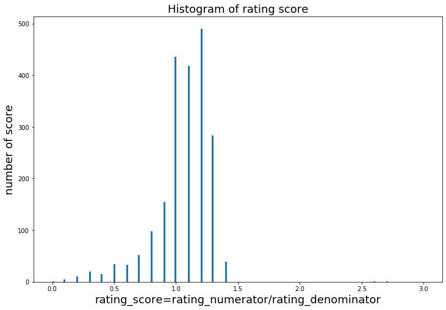

```python
# get a histogram
plt.figure(figsize = (12,8))
plt.hist(twitter_archive_master.rating,bins = 200,range = (0,3))
plt.xlabel('rating_score=rating_numerator/rating_denominator',fontsize = 18)
plt.ylabel('number of score',fontsize = 18)
plt.title('Histogram of rating score',fontsize = 18)
plt.show()
```

**conclusion**: WeRateDogs like to give scores around 1.0 to 1.3. And their rating are left skewed, means they do not like to give a much higher score.

##### (2) analyze retweet_count

```python
twitter_archive_master.retweet_count.describe()
```

```
count    2089.000000
mean     2570.303016
std      4498.746937
min      11.000000
25%      569.000000
50%      1246.000000
75%      2925.000000
max      79284.000000
Name: retweet_count, dtype: float64
```

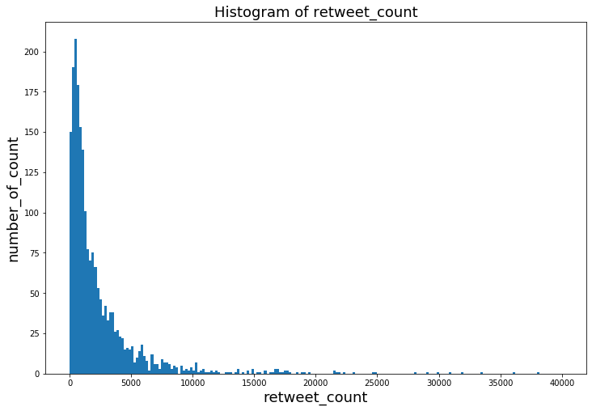

```python
# get a histogram
plt.figure(figsize = (12,8))
plt.hist(twitter_archive_master.retweet_count,bins = 200,range = (0,40000))
plt.xlabel('retweet_count',fontsize = 18)
plt.ylabel('number_of_count',fontsize = 18)
plt.title('Histogram of retweet_count',fontsize = 18)
plt.show()
```

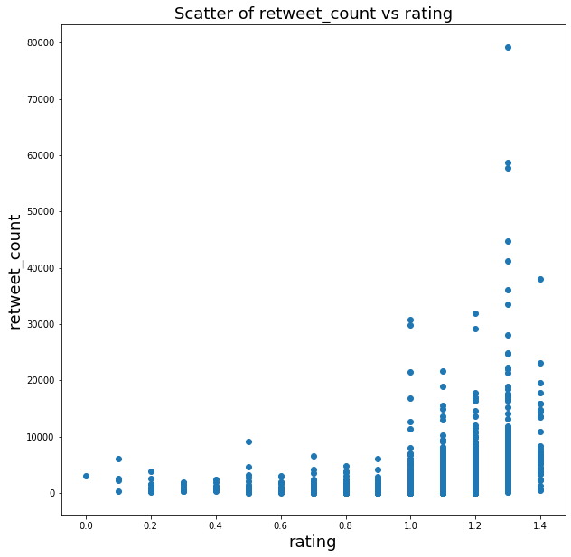

```python
# get a scatter plot of retweet_count and rating
# in order to get rid of the outliers, I filter out sevel extram large ratings
twitter_archive_master_no_outliers = twitter_archive_master[twitter_archive_master.rating <=2.5]
plt.figure(figsize = (10,10))
plt.scatter(x = twitter_archive_master_no_outliers.rating,y = twitter_archive_master_no_outliers.retweet_count)
plt.xlabel('rating',fontsize = 18)
plt.ylabel('retweet_count',fontsize = 18)
plt.title('Scatter of retweet_count vs rating',fontsize = 18)
plt.show()
```

**Conclusion**:

- most of the tweets have been retweeted for less than 5000 times,
- The higher the rating, the more likely people retweet

##### (3) analyze favorite_count

I will do the same analyzing as above

```python
twitter_archive_master.favorite_count.describe()
```

```
count    2089.000000
mean     8481.296793
std      12314.924125
min      73.000000
25%      1884.000000
50%      3875.000000
75%      10585.000000
max      158903.000000
Name: favorite_count, dtype: float64
```

```python
twitter_archive_master[twitter_archive_master.favorite_count == 158903]
```

|  | tweet_id | timestamp | source | text | expanded_urls | rating_numerator | rating_denominator | name | retweet_count | favorite_count | stage | rating |
| --- | --- | --- | --- | --- | --- | --- | --- | --- | --- | --- | --- | --- |
| 819 | 744234799360020481 | 2016-06-18 18:26:18 +0000 | Twitter for iPhone | Here's a doggo realizing you can stand in a pool. 13/10 enlightened af (vid by Tina Conrad) https://t.co/7wE9LTEXC4 | https://twitter.com/dog_rates/status/744234799360020481/video/1 | 13 | 10 | None | 79284 | 158903 | doggo | 1.3 |

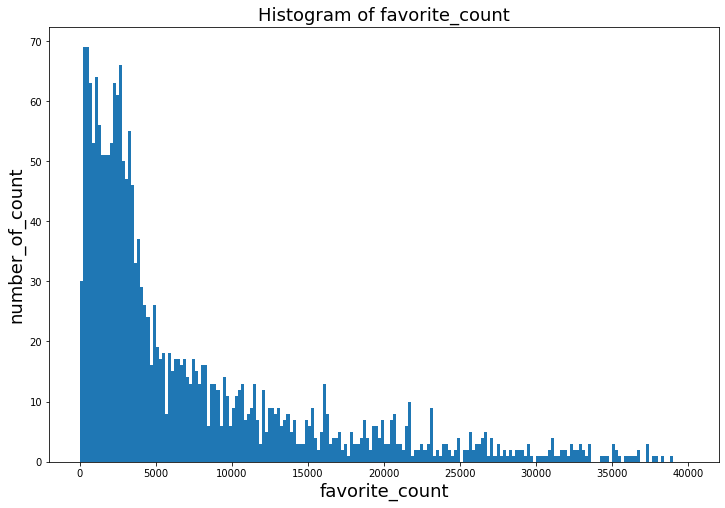

```python
# get a histogram
plt.figure(figsize = (12,8))
plt.hist(twitter_archive_master.favorite_count,bins = 200,range = (0,40000))
plt.xlabel('favorite_count',fontsize = 18)
plt.ylabel('number_of_count',fontsize = 18)
plt.title('Histogram of favorite_count',fontsize = 18)
plt.show()
```

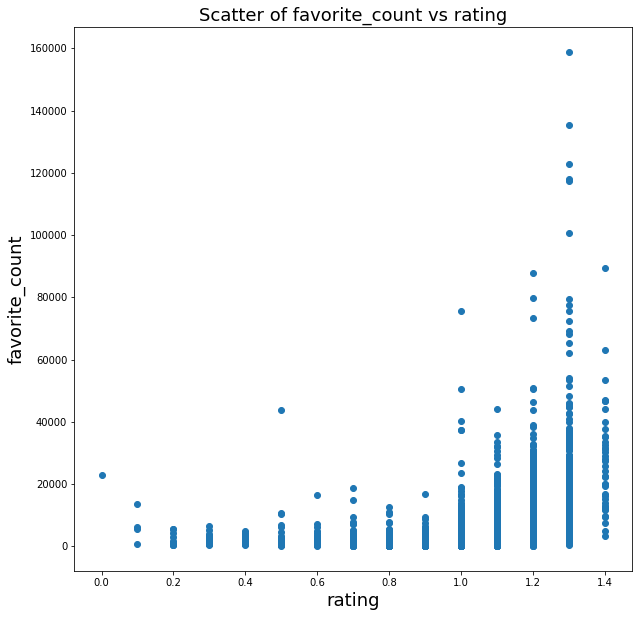

```python
# get a scatter plot of retweet_count and rating
# in order to get rid of the outliers, I filter out sevel extram large ratings
twitter_archive_master_no_outliers = twitter_archive_master[twitter_archive_master.rating <=2.5]
plt.figure(figsize = (10,10))
plt.scatter(x = twitter_archive_master_no_outliers.rating,y = twitter_archive_master_no_outliers.favorite_count)
plt.xlabel('rating',fontsize = 18)
plt.ylabel('favorite_count',fontsize = 18)
plt.title('Scatter of favorite_count vs rating',fontsize = 18)
plt.show()
```

**Conclusion**:

- most of the tweets have been favorited for less than 10000 times,
- The higher the rating, the more likely people favorite.

##### (4) analyze dog stages

```python
twitter_archive_master.stage.count()
```

```
336
```

```python
# get a smaller table with stage column not null
df_stage = twitter_archive_master[twitter_archive_master.stage.notnull()]
```

```python
# get the average rating of each stage
print(twitter_archive_master[twitter_archive_master.stage == 'doggo'].rating.mean())
print(twitter_archive_master[twitter_archive_master.stage == 'puppo'].rating.mean())
print(twitter_archive_master[twitter_archive_master.stage == 'pupper'].rating.mean())
print(twitter_archive_master[twitter_archive_master.stage == 'floofer'].rating.mean())
```

```
1.1839999999999995
1.2041666666666668
1.0841409691629944
1.1800000000000002
```

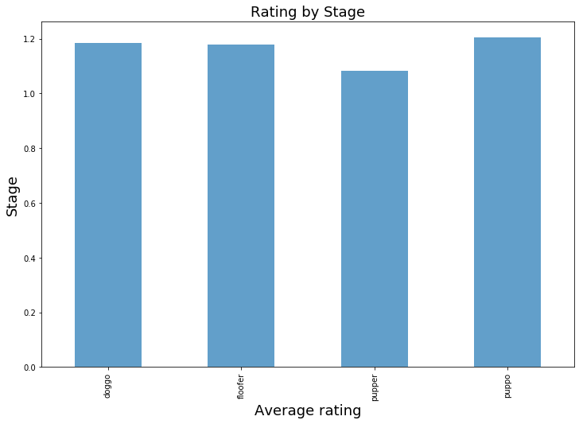

```python
plt.figure(figsize = (12,8)
rating = df_stage.groupby(['stage']).mean()['rating']
rating.plot(kind = 'bar',alpha = .7)
plt.xlabel('Average rating',fontsize = 18)
plt.ylabel('Stage',fontsize = 18)
plt.title('Rating by Stage',fontsize = 18)
```

**Conclusion:**

- Only 16.1% of tweets have stage information. (336/2089=0.16084)
- puppo have the highest average rating, pupper have the lowest
- Overall there is no obviously difference of each stages

##### (5) analyze image_predictions

```python
# get the number of rows
print(image_predictions_master.p1.count())

# get the number of kinds of the breeds
print(image_predictions_master.p1.nunique())

# get the detail of the breeds
print(image_predictions_master.p1.value_counts())

# get the dog breeds list
dog_name_list = list(image_predictions_master.p1.value_counts().index)

# get the list of numbers of breeds
dog_count_list = list(image_predictions_master.p1.value_counts())

# count the first 20 popular breeds
print(dog_name_list[:20])
print(dog_count_list[:20])

# count the total number of tweets of the first 20 breeds
n = 0
for i in dog_count_list[:20]:
    n += i
print(n)

# get the precentage of the total first 20 breeds
print(n/1751)
```

```
1751
113
golden_retriever                  173
Labrador_retriever                113
Pembroke                          96
Chihuahua                         95
pug                               65
toy_poodle                        52
chow                              51
Samoyed                           46
Pomeranian                        42
malamute                          34
cocker_spaniel                    34
French_bulldog                    32
Chesapeake_Bay_retriever          31
miniature_pinscher                26
Cardigan                          23
Staffordshire_bullterrier         22
Eskimo_dog                        22
German_shepherd                   21
beagle                            21
Siberian_husky                    20
Shih-Tzu                          20
Shetland_sheepdog                 19
Maltese_dog                       19
Lakeland_terrier                  19
Rottweiler                        19
kuvasz                            19
Italian_greyhound                 17
basset                            17
American_Staffordshire_terrier    16
West_Highland_white_terrier       16
Old_English_sheepdog              15
soft-coated_wheaten_terrier       15
Great_Pyrenees                    15
schipperke                        15
vizsla                            14
Pekinese                          14
dalmatian                         13
kelpie                            13
```

[output cut: 65 more lines]

```
wire-haired_fox_terrier           2
Appenzeller                       2
Scotch_terrier                    1
silky_terrier                     1
Bouvier_des_Flandres              1
standard_schnauzer                1
Japanese_spaniel                  1
clumber                           1
EntleBucher                       1
Irish_wolfhound                   1
Name: p1, dtype: int64
['golden_retriever', 'Labrador_retriever', 'Pembroke', 'Chihuahua', 'pug', 'toy_poodle', 'chow', 'Samoyed', 'Pomeranian', 'malamute', 'cocker_spaniel', 'French_bulldog', 'Chesapeake_Bay_retriever', 'miniature_pinscher', 'Cardigan', 'Staffordshire_bullterrier', 'Eskimo_dog', 'German_shepherd', 'beagl…
[173, 113, 96, 95, 65, 52, 51, 46, 42, 34, 34, 32, 31, 26, 23, 22, 22, 21, 21, 20]
1019
0.5819531696173615
```

- There are 113 dog breeds
- the most 20 popular breeds are 'golden_retriever', 'Labrador_retriever', 'Pembroke', 'Chihuahua', 'pug', 'toy_poodle', 'chow', 'Samoyed', 'Pomeranian', 'malamute', 'cocker_spaniel', 'French_bulldog', 'Chesapeake_Bay_retriever', 'miniature_pinscher', 'Cardigan', 'Staffordshire_bullterrier', 'Eskimo_dog', 'German_shepherd', 'beagle' and 'Siberian_husky'. These 20 kind of prediction totally have 1019 tweets, is 58.2% of the total

```python
# merge the p1 prediction from image_predictions with the twitter_archive_master
df_total = pd.merge(twitter_archive_master,image_predictions_master[['tweet_id','p1']],
                    on = 'tweet_id')
```

```python
#I want to filter out the 50 most breeds in total, these breeds have more than 10 tweet each.
df_total_first_50 = df_total[df_total.p1.isin(dog_name_list[:50])]
df_total_first_50.count()
```

```
tweet_id              1372
timestamp             1372
source                1372
text                  1372
expanded_urls         1372
rating_numerator      1372
rating_denominator    1372
name                  984
retweet_count         1372
favorite_count        1372
stage                 213
rating                1372
p1                    1372
dtype: int64
```

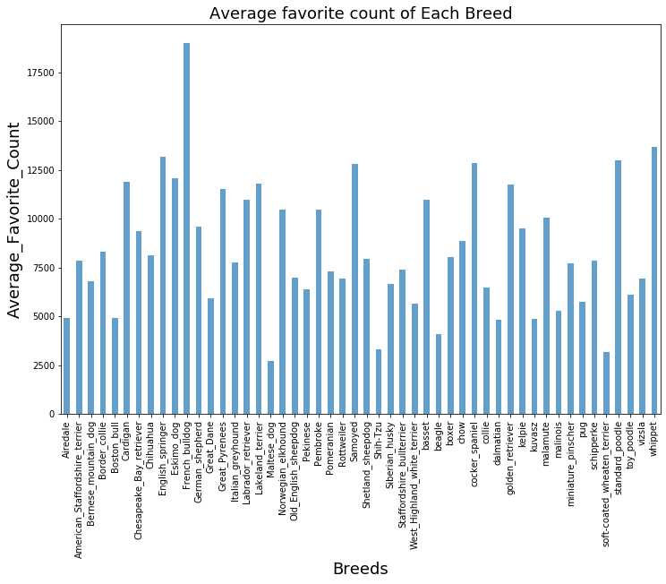

```python
# get the bar chart of the average favorite_count for each breed
plt.figure(figsize = (12,8))
breeds_rating= df_total_first_50.groupby(['p1']).mean()['favorite_count']
breeds_rating.plot(kind = 'bar',alpha = .7)
plt.xlabel('Breeds',fontsize = 18)
plt.ylabel('Average_Favorite_Count',fontsize = 18)
plt.title('Average favorite count of Each Breed',fontsize = 18)
```

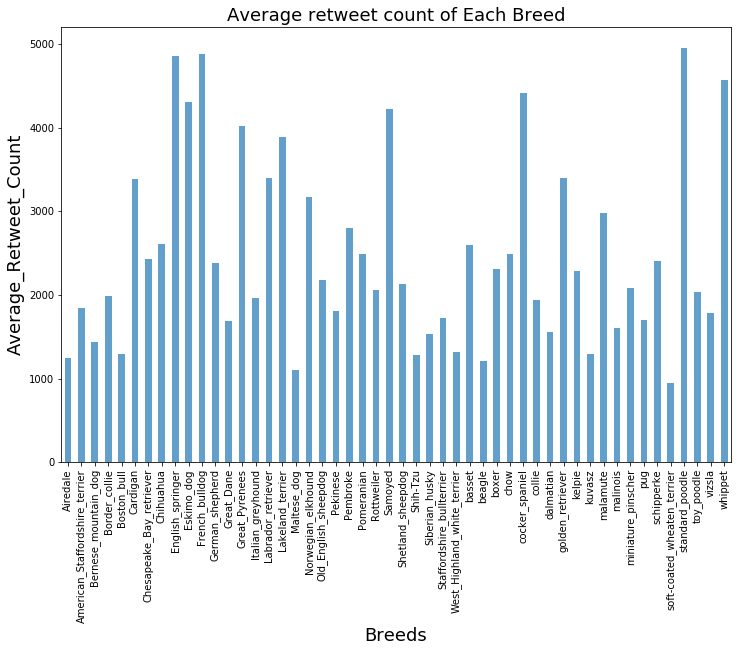

```python
# get the bar chart of the average retweet_count for each breed
plt.figure(figsize = (12,8))
breeds_rating= df_total_first_50.groupby(['p1']).mean()['retweet_count']
breeds_rating.plot(kind = 'bar',alpha = .7)
plt.xlabel('Breeds',fontsize = 18)
plt.ylabel('Average_Retweet_Count',fontsize = 18)
plt.title('Average retweet count of Each Breed',fontsize = 18)
```

From above two charts, Cardingan, English_springer, Eskimo_dog, French_bulldog, Great_pyrenees, labrador_retrievert, lakeland_terriever, amoyed, cocker_spaniel, golden_retriever, standard_poodle and whippet have the most faverate count and retweet count.

I searched some basic information about these 12 breeds. I found:

**Cardingan , English_springer, Great_pyrenees, labrador_retrievert, samoyed, cocker_spaniel, golden_retriever,standard_poodle, whippet** are large dogs

**Eskimo_dog, French_bulldog, lakeland_terriever** are small and medium dogs.

- It is possilbe, people are more likely to favourite and retweet dogs of large body size.